# BST 260 Group Project

Christina, Dena, Jack, Veronica, Whitney

11/22/2021

```r
#some basic packages that we will probably want:
library(tidyverse)
library(lubridate)
library(rvest)
#package to read in xlsx files from a url:
library(openxlsx)
```

# Overview, Motivation, and Objectives

We seek to explore health disparities at the county level using the County Health Rankings - a program of the University of Wisconsin Population Health Institute. We chose this project as we are all interested in improving the quality and transparency of data analytics and visualizations that seek to describe health-related disparities and the structural determinants that contribute to them. We are also interested in better understanding best practices for using county-level data and small area based estimates as they are becoming increasingly popular in informing micro-level programs and policy decisions.

The overall goal of this project is to explore health-related disparities at the county level in the United States.

The specific objectives are to:

- Describe health disparities at the county level using the County Health Rankings - a program of the University of Wisconsin Population Health Institute.
- Explore ways to improve the quality and transparency of data analytics and visualizations that seek to describe health-related disparities and the structural determinants that contribute to them.
- Highlight key drivers of health-related disparities in order to support decision-making and equitable resource allocation.

The outcomes of interest were life expectancy and drug-related overdose mortality. This project is a work in progress and health-related outcomes and associated drivers will continue to get added for future iterations. As a pilot, life expectancy and drug-related mortality are highlighted as these were of particular interest to the research team. They also reflect outcomes that are pertinent to the current COVID-19 pandemic as drug overdose mortality has increased throughout the pandemic and counties with lower than average life expectancies are more vulnerable during the pandemic.

# Data and Analysis

In order to accomplish our goals, we completed 5 analyses:

1. We scraped data from multiple sources, cleaned and merged the appropriate columns for our outcomes and covariates of interest.
2. We conducted multiple types of data visualization to explore the range of outcomes data and their distribution across counties. This helped to highlight disparities. Data visualization of predictors of interest was also conducted to show their distribution across counties and allow for comparing predictors and outcomes using scatter plots in the interactive portion of our webpage.
3. We conducted generalized linear regression models and machine learning models (comparing logistic regression, naive bayes, and decision tree models) to identify modifiable variables of interest to local decision makers that are driving disparities in our outcomes of interest.
4. We developed a map to better visualize disparities across counties. As this project is focused on place-based inequities, we believed it was important to represent the data geographically and use different visualization techniques to help users better understand where the burden of disease may lie.
5. Finally, we developed a Shiny app to help users of the webpage better navigate the map and our predictors of interest. This app allows users to select counties of interest in order to see the relative burden of disease and to compare the strength of association across outcomes and variables of interest using an interactive scatter plot.

*Changes in our thinking process:* Some changes in our approach throughout the process included: the portions we chose to make interactive (after developing the map, we felt it would be a useful piece to be made interactive using a Shiny app), the presentation of Covid-19 related data (while we scraped Covid-19 data, we did not end up presenting it as we felt that it was no longer in line with our main objectives for the project and might distract from the outcomes and predictors of interest - however, we have kept the data available so that as we continue to work on the webpage, we can add more outcomes, including Covid-19 outcomes).

# Related Work and Inspiration

We were inspired by the methods introduced in class including web scraping of available online data, data visualization methods, machine learning for predictive modeling, mapping technique to present place-based data, and Shiny app integrations to make data presentation more user-friendly.

We were also motivated by what we viewed as place-based health challenges throughout the Covid-19 pandemic (making certain counties more vulnerable than others) and the dual epidemic of rising drug-related overdose mortality rate alongside rising Covid-19 cases. We believe that access to county-specific data to highlight health-related disparities and the distribution of social and structural determinants that contribute to them can be helpful in guiding local decision-making in addressing similar challenges in the future.

Finally, we were inspired by the County Health Rankings data project and other similar efforts such as CDC Places that try to make small area-based estimates available to the public. It was an important learning experience to see how the choice of analysis and decisions made regarding what to visualize and how can play a significant role in what appears as important to end users (in this case, decision makers).

# Final Take-aways

Throughout our analyses, we learned several important things:

- as expected, counties with higher rates of drug-related overdose mortality also exhibited lower average life expectancy.
- average life expectancy across counties in the US is normally distributed across a wide range (high disparity).
- drug-related overdose mortality has a right-skewed distribution with some counties experiencing very high rates.
- The three most important predictors of life expectency variations across counties based on the Decision Tree model included: percentage of population experiencing food insecurity, median household income, and percentage of population having some college education.
- The three most important predictors of drug-related overdose mortality variations across counties based on the Decision Tree model included: percentage of population experiencing insufficient sleep, percentage of population uninsured, and percentage of population unemployed.
- Using our shiny app, we can also see that some of these predictors display linear correlations with one another (eg. increasing food insecurity with decreasing median household income).

The rest of this document will display each analysis separately including code and notes.

# Analysis 1: Data scraping, cleaning and merging

Obtain County Health Ranking Data sheets, as well as county-level COVID data from NYT:

```r
#County Health Ranking Data:
dat <- read.xlsx("https://www.countyhealthrankings.org/sites/default/files/media/document/2021%20County%20Health%20Rankings%20Data%20-%20v1.xlsx", sheet = 4, startRow = 2)

#County Health Ranking Data second sheet:
dat2 <- read.xlsx("https://www.countyhealthrankings.org/sites/default/files/media/document/2021%20County%20Health%20Rankings%20Data%20-%20v1.xlsx", sheet = 6, startRow = 2)

#Cumulative County-level COVID data:
covid_dat <- read.csv(url("https://raw.githubusercontent.com/nytimes/covid-19-data/master/us-counties.csv"))
```

Web scraping for County names and population from Wikipedia:

```r
url <- "https://en.wikipedia.org/wiki/List_of_United_States_counties_and_county_equivalents"
tab = read_html(url) %>% html_nodes("table")

county_names <- c("county", "state", "population_2019", "delete")
counties <- tab %>% .[1] %>% html_table %>% .[[1]] %>% setNames(county_names)

counties <- counties %>%
  select(!delete)

#make population_2019 numeric:
counties$population_2019 <- as.numeric(gsub(",","", counties$population_2019))
```

Data Manipulation and Merging:

```r
#Filter COVID data to most recent date, then arrange by state:
covid_dat <- covid_dat %>%
  filter(date == '2021-11-21') %>%
  select(!fips) %>%
  arrange(state)

#Make a list of the column names that we're interested in for dat:
columns <- c("FIPS",    "State",    "County", "Years.of.Potential.Life.Lost.Rate", "%.Fair.or.Poor.Health", "Average.Number.of.Physically.Unhealthy.Days",  "Average.Number.of.Mentally.Unhealthy.Days",    "%.Low.birthweight",    "%.Smokers", "%.Adults.with.Obesity",   "Food.Environment.Index",   "%.Physically.Inactive",    "%.With.Access.to.Exercise.Opportunities",  "%.Excessive.Drinking", "#.Alcohol-Impaired.Driving.Deaths",    "#.Driving.Deaths", "%.Driving.Deaths.with.Alcohol.Involvement",    "Chlamydia.Rate",   "Teen.Birth.Rate",  "%.Uninsured", "Primary.Care.Physicians.Rate",  "Primary.Care.Physicians.Ratio",    "Dentist.Rate", "Dentist.Ratio",    "Mental.Health.Provider.Rate",  "Mental.Health.Provider.Ratio", "Preventable.Hospitalization.Rate", "%.With.Annual.Mammogram",  "%.Vaccinated", "%.Completed.High.School",  "%.Some.College",   "%.Unemployed", "%.Children.in.Poverty",    "Income.Ratio", "%.Children.in.Single-Parent.Households",   "Social.Association.Rate", "Violent.Crime.Rate",    "Injury.Death.Rate",    "Average.Daily.PM2.5",  "Presence.of.Water.Violation", "%.Severe.Housing.Problems", "%.Drive.Alone.to.Work", "%.Long.Commute.-.Drives.Alone")

#Keep only the columns from our list above, rename to match COVID data, arrange by state:
dat <- dat %>%
  select(columns) %>%
  rename(county = County) %>%
  rename(state = State) %>%
  rename(fips = FIPS) %>%
  arrange(state)
```

```
## Note: Using an external vector in selections is ambiguous.
## i Use `all_of(columns)` instead of `columns` to silence this message.
## i See <https://tidyselect.r-lib.org/reference/faq-external-vector.html>.
```

```r
#Make a list of the column names we're interested in for dat2:
columns2 <- c("FIPS",   "State",    "County", "Life.Expectancy",    "Age-Adjusted.Death.Rate",  "Child.Mortality.Rate", "Infant.Mortality.Rate",    "%.Frequent.Physical.Distress", "%.Frequent.Mental.Distress",   "%.Adults.with.Diabetes",   "HIV.Prevalence.Rate",  "%.Food.Insecure",  "%.Limited.Access.to.Healthy.Foods",    "Drug.Overdose.Mortality.Rate", "Motor.Vehicle.Mortality.Rate", "%.Insufficient.Sleep", "%.Disconnected.Youth", "Average.Grade.Performance",    "Median.Household.Income",  "%.Enrolled.in.Free.or.Reduced.Lunch",  "Homicide.Rate",    "Suicide.Rate.(Age-Adjusted)",  "Firearm.Fatalities.Rate",  "Juvenile.Arrest.Rate", "%.Homeowners", "%.Broadband.Access",   "%.Female", "%.Rural")

#Keep only the columns from our list above, rename to match COVID data, arrange by state:
dat2 <- dat2 %>%
  select(columns2) %>%
  rename(county = County) %>%
  rename(state = State) %>%
  rename(fips = FIPS) %>%
  arrange(state)
```

```
## Note: Using an external vector in selections is ambiguous.
## i Use `all_of(columns2)` instead of `columns2` to silence this message.
## i See <https://tidyselect.r-lib.org/reference/faq-external-vector.html>.
```

```r
#Merge dat with dat2, then merge with COVID data:
dat <- dat %>%
  inner_join(dat2, by=c("county", "state"))

dat <- dat %>%
  left_join(covid_dat, by=c("county", "state"))

#Finally, merge dat with counties for population:
dat <- dat %>%
  left_join(counties, by=c("county", "state"))
```

# Analysis 2: Data Visualizations

## Analysis 2.2: Boxplot of median household income per state

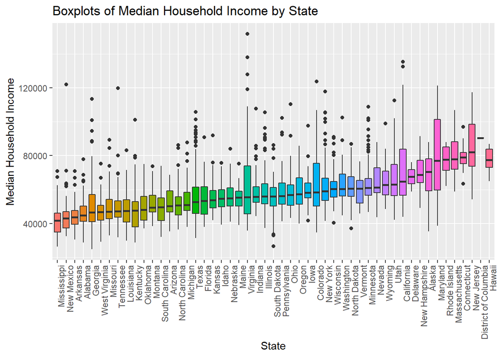

```r
##box plot of household income per state
p <- dat %>%
  mutate(state = reorder(state, Median.Household.Income, FUN = median)) %>%
  ggplot(aes(state, Median.Household.Income, fill = state)) +
  geom_boxplot() +
  theme_bw() +
  ggtitle("Boxplots of Median Household Income by State")  +
  theme_update(plot.title = element_text(hjust = 0.6)) +
  theme(axis.text.x = element_text(angle = 90, hjust = 1)) +
  xlab("State") + ylab("Median Household Income")+
  theme(legend.position = "none")
p
```

## Analysis 2.3: Life Expectancy

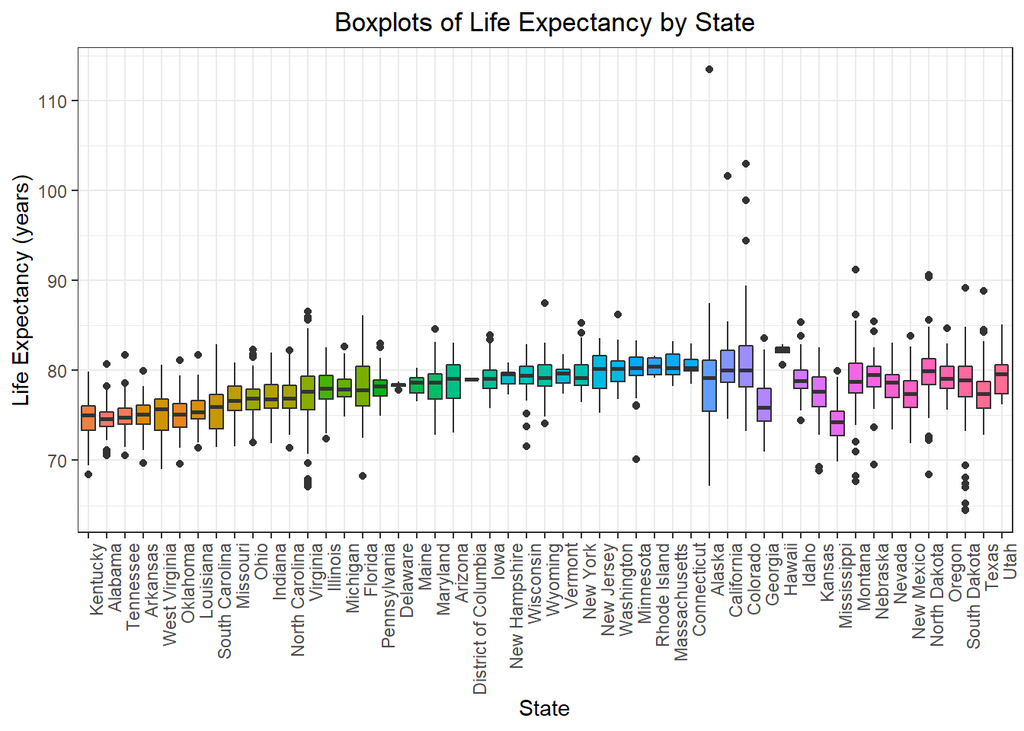

```r
#box plot of life expectancy by state
p2 <- dat %>%
  mutate(state = reorder(state, Life.Expectancy, FUN = median), is.na(Life.Expectancy)) %>%
  ggplot(aes(x = reorder(state, Life.Expectancy), y = Life.Expectancy, fill = state)) +
  geom_boxplot() +
  theme_bw() +
  theme(legend.position = "none") +
  theme(axis.text.x = element_text(angle = 90, hjust = 1)) +
  theme(plot.title = element_text(hjust = 0.5)) +
  ggtitle("Boxplots of Life Expectancy by State") +
  xlab("State") + ylab("Life Expectancy (years)")

p2
```

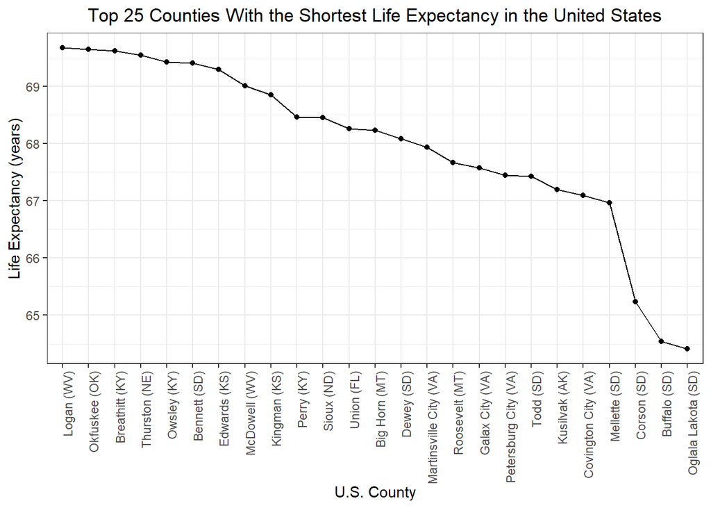

```r
###Extra code to assess individual state statistics
#something <- dat %>% select(state, Life.Expectancy, county) %>% group_by(state) %>%
#                mutate(median_life = median(Life.Expectancy)) %>% ungroup()
#something

#something2 <- dat %>% filter(state == "Mississippi", !is.na(Life.Expectancy))
##something2
#median(something2$Life.Expectancy)

#code to determine distribution of life expectancy variable
#mean(dat$Life.Expectancy, na.rm = TRUE)
#min(dat$Life.Expectancy, na.rm = TRUE)
#summary(dat$Life.Expectancy)


#selecting the top 24 counties with the lowest life expectancy
p3 <- dat %>% select(county, state, Life.Expectancy) %>% arrange(Life.Expectancy)%>%
          filter(Life.Expectancy <= 69.7)

#creating a line plot of descending order of life expectancy
p4 <- p3 %>% ggplot(aes(x = reorder(county, -Life.Expectancy), y = Life.Expectancy, group = 1)) +
            geom_point() +
            geom_line() +
            theme_bw() +
            ggtitle("Top 25 Counties With the Shortest Life Expectancy in the United States") +
            theme(plot.title = element_text(hjust = 0.5)) +
            theme(axis.text.x = element_text(angle = 90, hjust = 1)) +
            xlab("U.S County") + ylab("Life Expectancy (years)")

#adding state abbreviations to county line plot
p4 + scale_x_discrete("U.S. County", labels = c("Oglala Lakota" = "Oglala Lakota (SD)", "Buffalo" = " Buffalo (SD)", "Corson" = "Corson (SD)", "Mellette" = " Mellette (SD)", "Covington City" = "Covington City (VA)" , "Kusilvak" = "Kusilvak (AK)", "Todd" = " Todd (SD)", "Petersburg City" = "Petersburg City (VA)", "Galax City" = "Galax City (VA)", "Roosevelt" = "Roosevelt (MT)", "Martinsville City" = "Martinsville City (VA)", "Dewey" = "Dewey (SD)", "Big Horn" = "Big Horn (MT)", "Union" = "Union (FL)", "Sioux" = "Sioux (ND)", "Perry" = "Perry (KY)",  "Kingman" = "Kingman (KS)", "McDowell" = "McDowell (WV)", "Edwards" = "Edwards (KS)", "Bennett" = "Bennett (SD)", "Owsley" = "Owsley (KY)", "Thurston" = "Thurston (NE)", "Breathitt" = "Breathitt (KY)", "Okfuskee" = "Okfuskee (OK)", "Logan" = "Logan (WV)"))
```

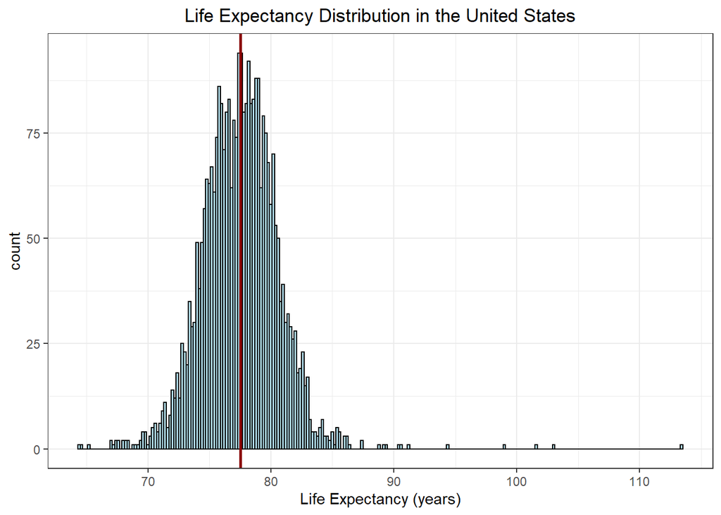

```r
##histogram of life expectancy in the united states
p5 <- dat %>% ggplot(aes(x = Life.Expectancy)) +
              geom_histogram(binwidth = 0.2, color = "black", fill = "light blue") +
              theme_bw()+
              ggtitle("Life Expectancy Distribution in the United States") +
              theme(plot.title = element_text(hjust = 0.5)) +
              xlab("Life Expectancy (years)")

p5 + geom_vline(aes(xintercept = mean(Life.Expectancy, na.rm = TRUE)), col='dark red',size=1)
```

```r
#Code for distribution statistics
#sd(dat$Life.Expectancy, na.rm = TRUE)
#mean(dat$Life.Expectancy, na.rm = TRUE)
```

## Analysis 2.4: Drug overdose mortality rate

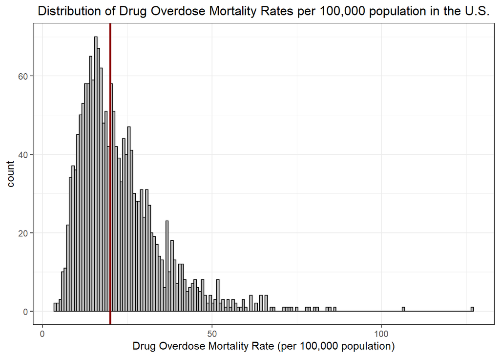

```r
#####Drug Overdose Mortality
#Histogram for drug overdose Mortality variable
p6 <- dat %>% ggplot(aes(x = `Drug.Overdose.Mortality.Rate`)) +
              geom_histogram(binwidth = 0.75, color = "black", fill = "gray") +
              theme_bw()+
              ggtitle("Distribution of Drug Overdose Mortality Rates per 100,000 population in the U.S.") +
              theme(plot.title = element_text(hjust = 0.5)) +
              xlab("Drug Overdose Mortality Rate (per 100,000 population)")
p6 + geom_vline(aes(xintercept = median(`Drug.Overdose.Mortality.Rate`, na.rm = TRUE)), col='dark red',size=1)
```

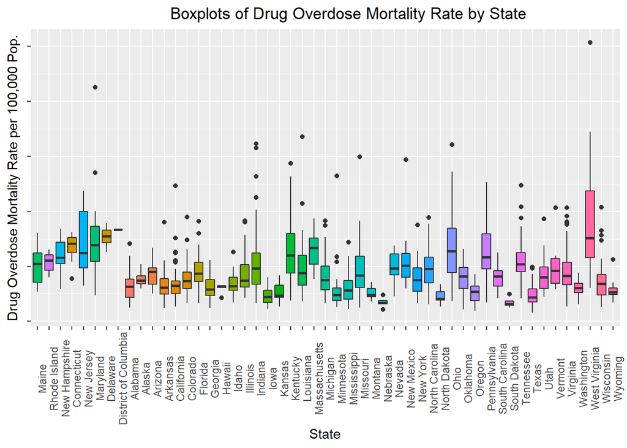

```r
#Code for distribution statistics
#median(dat$`Drug.Overdose.Mortality.Rate`, na.rm = TRUE)
#IQR(dat$`Drug.Overdose.Mortality.Rate`, na.rm = TRUE)
#max(dat$`Drug.Overdose.Mortality.Rate`, na.rm = TRUE)

#boxplot of drug overdose mortality rate by state
p7 <- dat %>%
  ggplot(aes(x = reorder(state, Drug.Overdose.Mortality.Rate) , y = Drug.Overdose.Mortality.Rate, fill = state))+
  geom_boxplot() +
  theme_bw() +
  ggtitle("Boxplots of Drug Overdose Mortality Rate by State")  +
  theme_update(plot.title = element_text(hjust = 0.5)) +
  theme(axis.text.x = element_text(angle = 90, hjust = 0.5)) +
  theme(axis.text.y = element_text(size = 0.1)) + ##need to adjust the size of text
  xlab("State") + ylab("Drug Overdose Mortality Rate per 100,000 Pop.")+ #change size of text
  theme(legend.position = "none")

p7
```

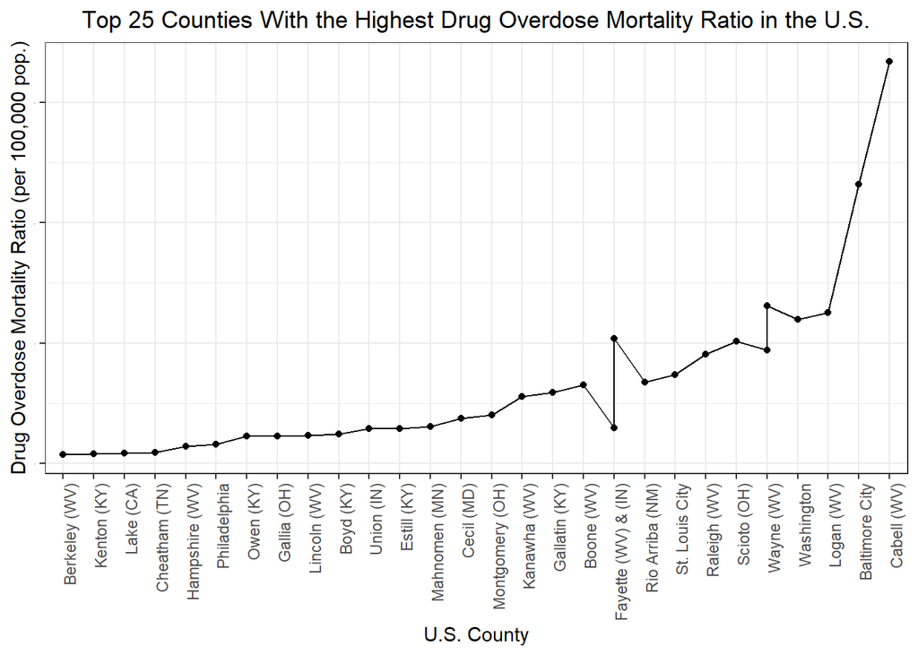

```r
###Extra code to assess individual state statistics
#something2 <- dat %>% filter(state == "West Virginia", !is.na(Drug.Overdose.Mortality.Rate))
#something2

#code to determine the top 25 counties with highest drug overdose mortality rate
p8 <- dat %>% select(county, state, Drug.Overdose.Mortality.Rate) %>% arrange(Drug.Overdose.Mortality.Rate) %>%
          filter(Drug.Overdose.Mortality.Rate >= 61)

#creating a line plot of ascending order of drug overdose mortality rate
p9 <- p8 %>% ggplot(aes(x = reorder(county, Drug.Overdose.Mortality.Rate), y = Drug.Overdose.Mortality.Rate, group = 1)) +
            geom_point() +
            geom_line() +
            theme_bw() +
            theme(plot.title = element_text(hjust = 0.5)) +
            theme(axis.text.x = element_text(angle = 90, hjust = 1)) +
            theme(axis.text.y = element_text(size = 0.5)) +
            ggtitle("Top 25 Counties With the Highest Drug Overdose Mortality Ratio in the U.S.") +
            xlab("U.S County") + ylab("Drug Overdose Mortality Ratio (per 100,000 pop.)")

#adding state abbreviations to county line plot
p9 + scale_x_discrete("U.S. County", labels = c("Kenton" = "Kenton (KY)", "Lake" = " Lake (CA)", "Cheatham" = "Cheatham (TN)", "Hampshire" = " Hampshire (WV)", "Owen" = "Owen (KY)", "Gallia" = "Gallia (OH)", "Lincoln" = "Lincoln (WV)", "Boyd" = "Boyd (KY)", "Union" = "Union (IN)", "Estill" = "Estill (KY)", "Fayette" = "Fayette (WV) & (IN)", "Mahnomen" = "Mahnomen (MN)", "Cecil" = "Cecil (MD)", "Montgomery" = "Montgomery (OH)", "Kanawha" = "Kanawha (WV)", "Gallatin" = "Gallatin (KY)", "Boone" = "Boone (WV)", "Rio Arriba" = "Rio Arriba (NM)", "Raleigh" = "Raleigh (WV)", "Wayne" = "Wayne (IN)", "Scioto" = "Scioto (OH)", "Logan" = "Logan (WV)", "Wayne" = "Wayne (WV)", "Cabell" = "Cabell (WV)", "Berkeley" = "Berkeley (WV)"))
```

## Analysis 2.5: Scatter plot of life expectancy vs. drug over dose mortality rate

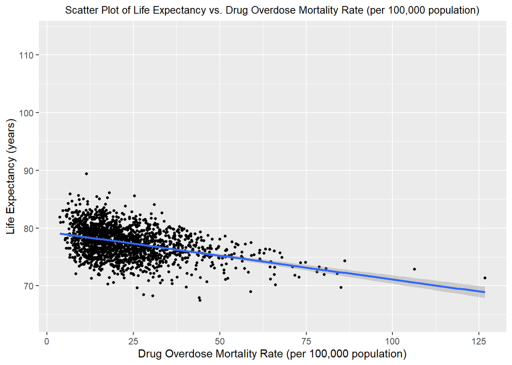

```r
###Scatter plot of drug over dose mortality and life expectancy
p10 <- dat %>% ggplot(aes(x = Drug.Overdose.Mortality.Rate, y = Life.Expectancy)) +
            geom_point(size = 1) +
            ggtitle("Scatter Plot of Life Expectancy vs. Drug Overdose Mortality Rate (per 100,000 population)") +
            theme(plot.title = element_text(size = 10)) +
            xlab("Drug Overdose Mortality Rate (per 100,000 population)") +
            ylab("Life Expectancy (years)")

#adding a trend line to the scatter plot
p10 + geom_smooth(method = "lm")
```

## Analysis 2.6: Food Insecurity

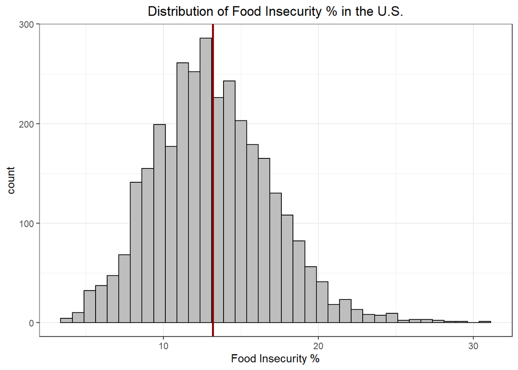

```r
####Food Insecurity
#histogram of food insecurity
p_food <- dat %>% ggplot(aes(x = `%.Food.Insecure`)) +
              geom_histogram(binwidth = 0.75, color = "black", fill = "gray") +
              theme_bw()+
              ggtitle("Distribution of Food Insecurity % in the U.S.") +
              theme(plot.title = element_text(hjust = 0.5)) +
              xlab("Food Insecurity %")

#code to add line where the mean value is located
p_food + geom_vline(aes(xintercept = mean(`%.Food.Insecure`, na.rm = TRUE)), col='dark red',size=1)
```

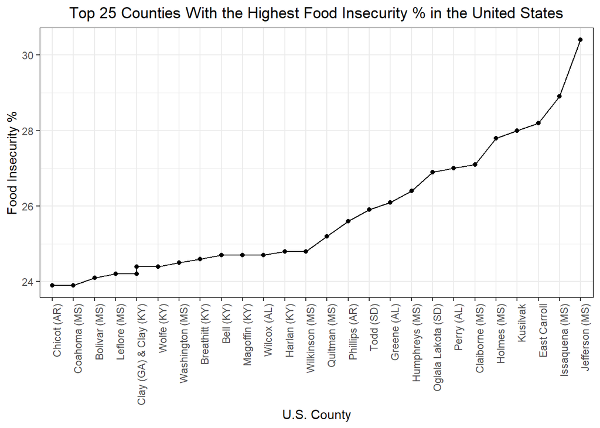

```r
#code for distribution statistics
#mean(dat$`%.Food.Insecure`, na.rm = TRUE)
#sd(dat$`%.Food.Insecure`, na.rm = TRUE)

#selecting the top 25 counties with the highest food insecurity %
p11 <- dat %>% select(county, state, `%.Food.Insecure`) %>% arrange(`%.Food.Insecure`)%>%
          filter(`%.Food.Insecure` >= 23.9)

#creating a line plot of ascending order of food insecurity %
p12 <- p11 %>% ggplot(aes(x = reorder(county, `%.Food.Insecure`), y = `%.Food.Insecure`, group = 1)) +
            geom_point() +
            geom_line() +
            theme_bw() +
            ggtitle("Top 25 Counties With the Highest Food Insecurity % in the United States") +
            theme(plot.title = element_text(hjust = 0.5)) +
            theme(axis.text.x = element_text(angle = 90, hjust = 1)) +
            xlab("U.S County") + ylab("Food Insecurity %")

#adding state abbreviations to county line plot
p12 + scale_x_discrete("U.S. County", labels = c("Chicot" = "Chicot (AR)", "Coahoma" = "Coahoma (MS)", "Bolivar" = "Bolivar (MS)", "Clay" = " Clay (GA) & Clay (KY)", "Leflore" = "Leflore (MS)", "Wolfe" = "Wolfe (KY)", "Washington" = "Washington (MS)", "Breathitt" = "Breathitt (KY)", "Wilcox" = "Wilcox (AL)", "Bell" = "Bell (KY)", "Magoffin" = "Magoffin (KY)", "Harlan" = "Harlan (KY)", "Wilkinson" = "Wilkinson (MS)", "Quitman" = "Quitman (MS)", "Phillips" = "Phillips (AR)", "Todd" = "Todd (SD)", "Greene" = "Greene (AL)", "Humphreys" = "Humphreys (MS)", "Oglala Lakota" = "Oglala Lakota (SD)", "Perry" = "Perry (AL)", "Claiborne" = "Claiborne (MS)", "Holmes" = "Holmes (MS)", "Issaquena" = "Issaquena (MS)", "Jefferson" = "Jefferson (MS)"))
```

## Analysis 2.7: Severe Housing Problems

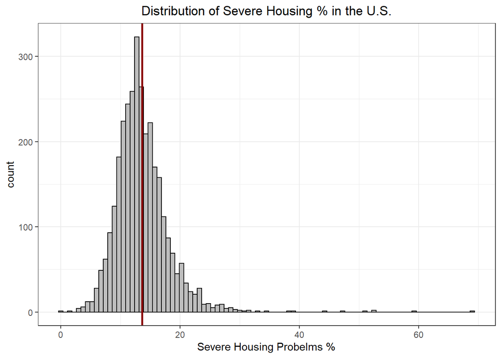

```r
#histogram of severe housing problems
p_housing <- dat %>% ggplot(aes(x = `%.Severe.Housing.Problems`)) +
              geom_histogram(binwidth = 0.75, color = "black", fill = "gray") +
              theme_bw()+
              ggtitle("Distribution of Severe Housing % in the U.S.") +
              theme(plot.title = element_text(hjust = 0.5)) +
              xlab("Severe Housing Probelms %")

#code to add line where the mean value is located
p_housing + geom_vline(aes(xintercept = mean(`%.Severe.Housing.Problems`, na.rm = TRUE)), col='dark red',size=1)
```

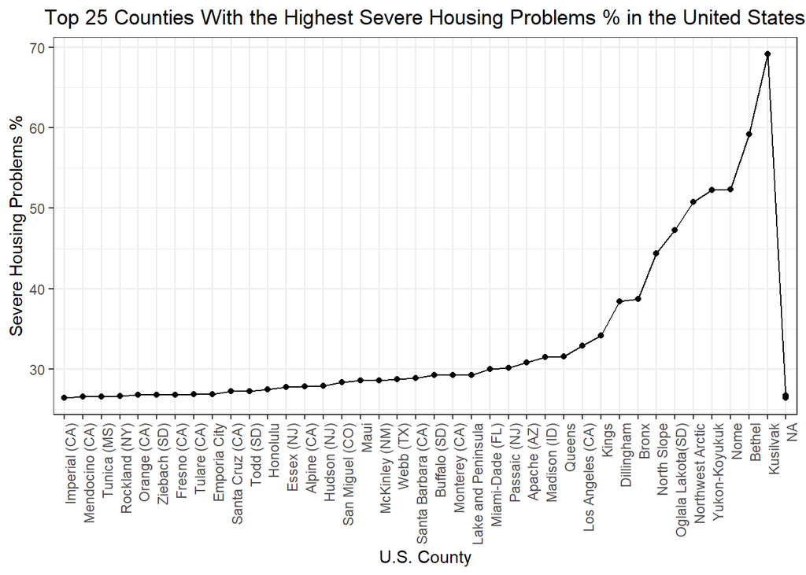

```r
#code for distribution statistics
#mean(dat$`%.Severe.Housing.Problems`, na.rm = TRUE)
#sd(dat$`%.Severe.Housing.Problems`, na.rm = TRUE)

#selecting the top 25 counties with the highest severe housing problems %
p13 <- dat %>% select(county, state, `%.Severe.Housing.Problems`) %>% arrange(`%.Severe.Housing.Problems`)%>%
          filter(`%.Severe.Housing.Problems` >= 26.43805)

#creating a line plot of ascending order of housing problems in top 25 counties
p14 <- p13 %>% ggplot(aes(x = reorder(county, `%.Severe.Housing.Problems`), y = `%.Severe.Housing.Problems`, group = 1)) +
            geom_point() +
            geom_line() +
            theme_bw() +
            ggtitle("Top 25 Counties With the Highest Severe Housing Problems % in the United States") +
            theme(plot.title = element_text(hjust = 0.5)) +
            theme(axis.text.x = element_text(angle = 90, hjust = 1)) +
            xlab("U.S County") + ylab("Severe Housing Problems %")

#adding state abbreviations to county line plot
p14 + scale_x_discrete("U.S. County", labels = c("Imperial" = "Imperial (CA)", "Mendocino" = "Mendocino (CA)", "Tunica" = "Tunica (MS)", "Rockland" = " Rockland (NY)", "Orange" = "Orange (CA)", "Ziebach" = "Ziebach (SD)", "Fresno" = "Fresno (CA)", "Tulare" = "Tulare (CA)", "Santa Cruz" = "Santa Cruz (CA)", "Todd" = "Todd (SD)", "Essex" = "Essex (NJ)", "Alpine" = "Alpine (CA)", "Hudson" = "Hudson (NJ)", "San Miguel" = "San Miguel (CO)", "McKinley" = "McKinley (NM)", "Webb" = "Webb (TX)", "Santa Barbara" = "Santa Barbara (CA)", "Buffalo" = "Buffalo (SD)", "Monterey" = "Monterey (CA)", "Miami-Dade" = "Miami-Dade (FL)", "Passaic" = "Passaic (NJ)", "Apache" = "Apache (AZ)", "Madison" = "Madison (ID)", "Los Angeles" = "Los Angeles (CA)", "Oglala Lakota" = "Oglala Lakota  (SD)"))
```

## Analysis 2.8: Some College

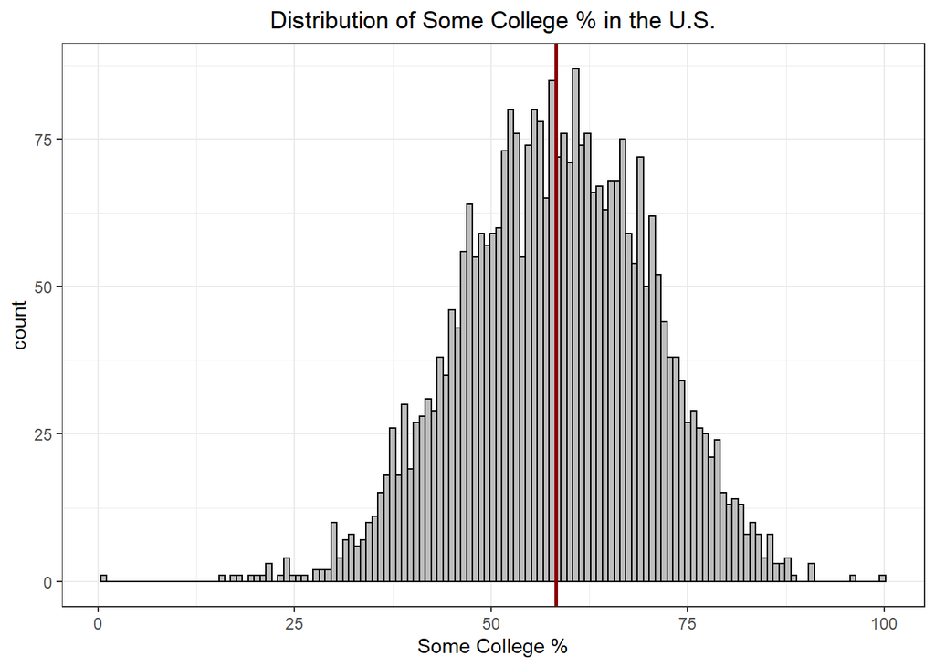

```r
#histogram of some college variable
p_college <- dat %>% ggplot(aes(x = `%.Some.College`)) +
              geom_histogram(binwidth = 0.75, color = "black", fill = "gray") +
              theme_bw()+
              ggtitle("Distribution of Some College % in the U.S.") +
              theme(plot.title = element_text(hjust = 0.5)) +
              xlab("Some College %")

#code to add line where the mean value is located
p_college + geom_vline(aes(xintercept = mean(`%.Some.College`, na.rm = TRUE)), col='dark red',size=1)
```

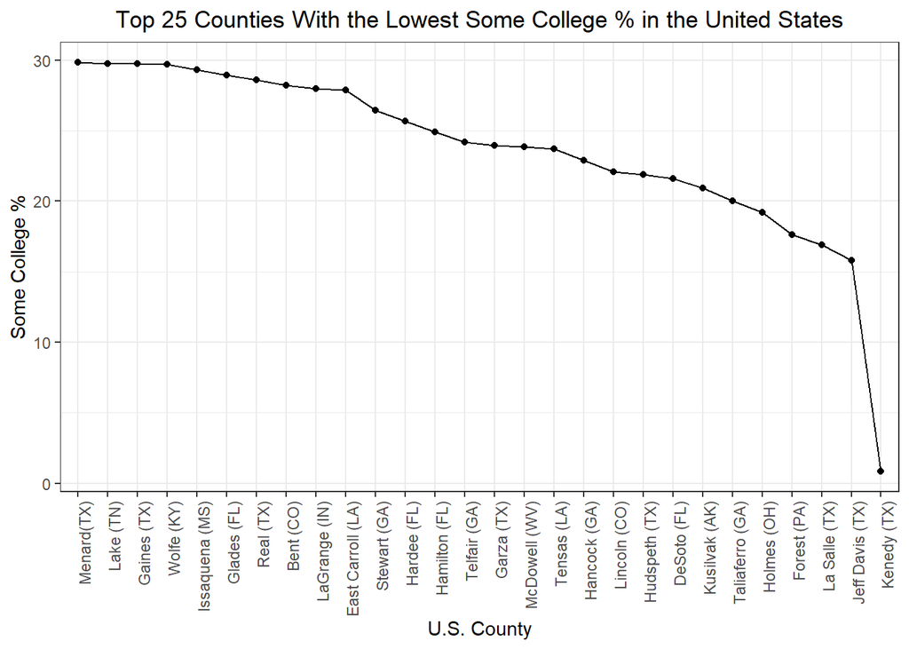

```r
#code for distribution statistics
#mean(dat$`%.Some.College`, na.rm = TRUE)
#sd(dat$`%.Some.College`, na.rm = TRUE)


#selecting the top 25 counties with the lowest some college %
p14 <- dat %>% select(county, state, `%.Some.College`) %>% arrange(`%.Some.College`)%>%
          filter(`%.Some.College` < 29.86)

#line plot for uninsured in the top 25 counties
p15 <- p14 %>% ggplot(aes(x = reorder(county, -`%.Some.College`), y = `%.Some.College`, group = 1)) +
            geom_point() +
            geom_line() +
            theme_bw() +
            ggtitle("Top 25 Counties With the Lowest Some College % in the United States") +
            theme(plot.title = element_text(hjust = 0.5)) +
            theme(axis.text.x = element_text(angle = 90, hjust = 1)) +
            xlab("U.S County") + ylab("Some College %")

#adding state abbreviations to county line plot
p15 + scale_x_discrete("U.S. County", labels = c("Kenedy" = "Kenedy (TX)", "Jeff Davis" = "Jeff Davis (TX)", "La Salle" = "La Salle (TX)", "Forest" = " Forest (PA)", "Holmes" = "Holmes (OH)", "Taliaferro" = "Taliaferro (GA)", "Kusilvak" = "Kusilvak (AK)", "DeSoto" = "DeSoto (FL)", "Hudspeth" = "Hudspeth (TX)", "Lincoln" = "Lincoln (CO)", "Hancock" = "Hancock (GA)", "Tensas" = "Tensas (LA)", "McDowell" = "McDowell (WV)", "Garza" = "Garza (TX)", "Telfair" = "Telfair (GA)", "Hamilton" = "Hamilton (FL)", "Hardee" = "Hardee (FL)", "Stewart" = "Stewart (GA)", "East Carroll" = "East Carroll (LA)", "LaGrange" = "LaGrange (IN)", "Bent" = "Bent (CO)", "Real" = "Real (TX)", "Glades" = "Glades (FL)", "Issaquena" = "Issaquena (MS)", "Wolfe" = "Wolfe (KY)", "Gaines" = "Gaines (TX)", "Lake" = "Lake (TN)", "Menard" = "Menard    (TX)"))
```

## Analysis 2.9: Uninsured

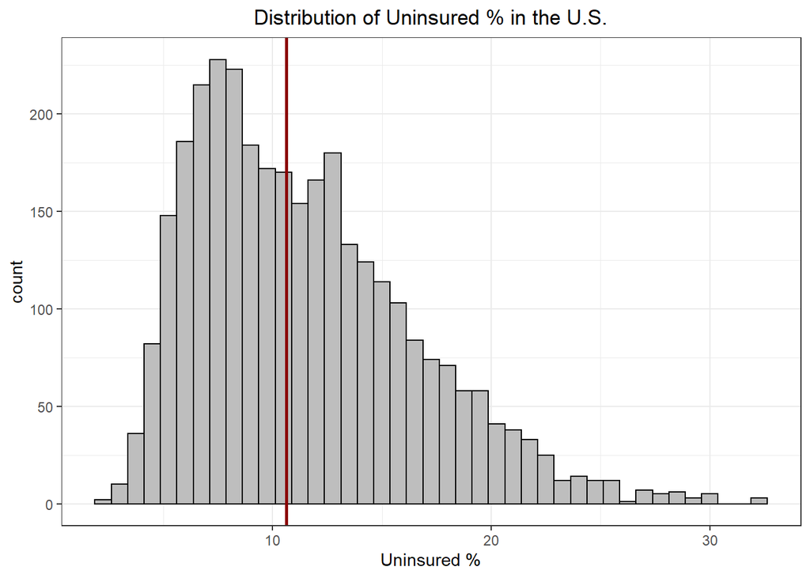

```r
#histogram of uninsured variable
p_uninsured <- dat %>% ggplot(aes(x = `%.Uninsured`)) +
              geom_histogram(binwidth = 0.75, color = "black", fill = "gray") +
              theme_bw()+
              ggtitle("Distribution of Uninsured % in the U.S.") +
              theme(plot.title = element_text(hjust = 0.5)) +
              xlab("Uninsured %")

#code to add line where the median value is located
p_uninsured + geom_vline(aes(xintercept = median(`%.Uninsured`, na.rm = TRUE)), col='dark red',size=1)
```

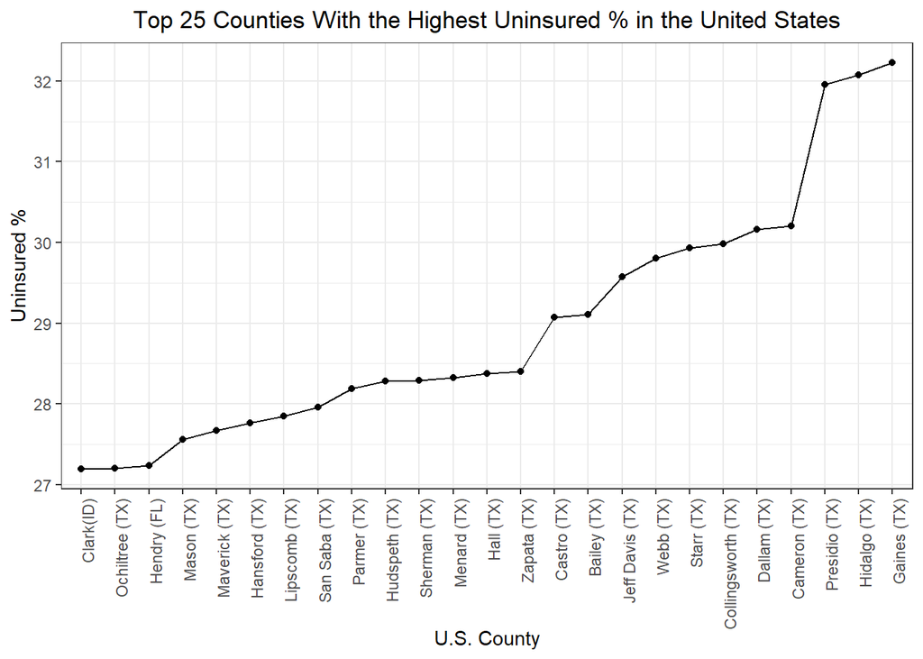

```r
#code for distribution statistics
#median(dat$`%.Uninsured`, na.rm = TRUE)
#IQR(dat$`%.Uninsured`, na.rm = TRUE)

#selecting the top 25 counties with the highest uninsured %
p16 <- dat %>% select(county, state, `%.Uninsured`) %>% arrange(desc(`%.Uninsured`))%>%
          filter(`%.Uninsured` > 27.1)

#line plot for uninsured in the top 25 counties
p17 <- p16 %>% ggplot(aes(x = reorder(county, `%.Uninsured`), y = `%.Uninsured`, group = 1)) +
            geom_point() +
            geom_line() +
            theme_bw() +
            ggtitle("Top 25 Counties With the Highest Uninsured % in the United States") +
            theme(plot.title = element_text(hjust = 0.5)) +
            theme(axis.text.x = element_text(angle = 90, hjust = 1)) +
            xlab("U.S County") + ylab("Uninsured %")

#adding state abbreviations to county line plot
p17 + scale_x_discrete("U.S. County", labels = c("Gaines" = "Gaines (TX)", "Hidalgo" = "Hidalgo (TX)", "Presidio" = "Presidio (TX)", "Cameron" = " Cameron (TX)", "Dallam" = "Dallam (TX)", "Collingsworth" = "Collingsworth (TX)", "Starr" = "Starr (TX)", "Webb" = "Webb (TX)", "Jeff Davis" = "Jeff Davis (TX)", "Bailey" = "Bailey (TX)", "Castro" = "Castro (TX)", "Zapata" = "Zapata (TX)", "Hall" = "Hall (TX)", "Menard" = "Menard (TX)", "Sherman" = "Sherman (TX)", "Hudspeth" = "Hudspeth (TX)", "Parmer" = "Parmer (TX)", "San Saba" = "San Saba (TX)", "Lipscomb" = "Lipscomb (TX)", "Hansford" = "Hansford (TX)", "Maverick" = "Maverick (TX)", "Mason" = "Mason (TX)", "Hendry" = "Hendry (FL)", "Ochiltree" = "Ochiltree (TX)", "Clark" = "Clark    (ID)"))
```

## Analysis 2.10: Unemployment

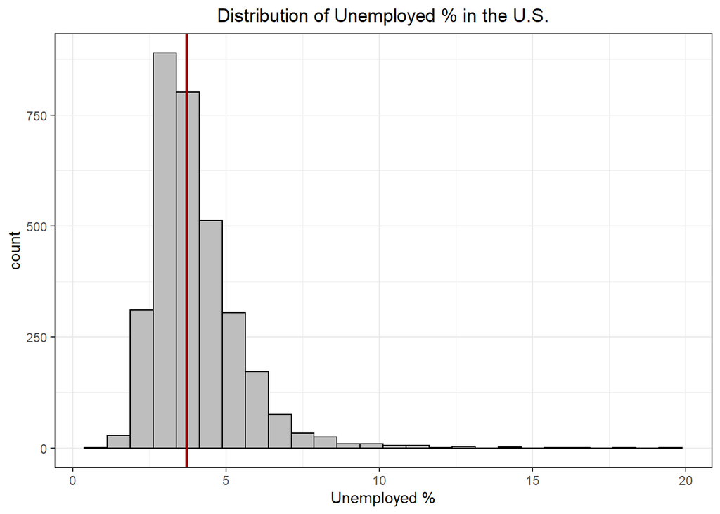

```r
#histogram of unemployment variable
p_unemployed <- dat %>% ggplot(aes(x = `%.Unemployed`)) +
              geom_histogram(binwidth = 0.75, color = "black", fill = "gray") +
              theme_bw()+
              ggtitle("Distribution of Unemployed % in the U.S.") +
              theme(plot.title = element_text(hjust = 0.5)) +
              xlab("Unemployed %")

#code to add line where the median value is located
p_unemployed + geom_vline(aes(xintercept = median(`%.Unemployed`, na.rm = TRUE)), col='dark red',size=1)
```

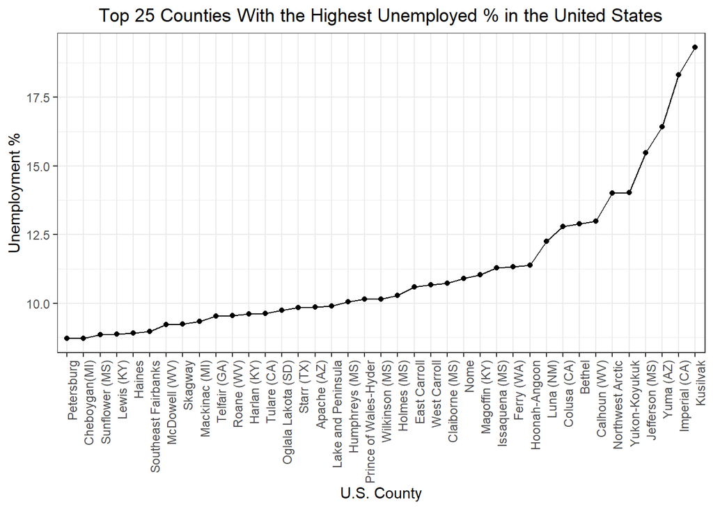

```r
#code for distribution statistics
#median(dat$`%.Unemployed`, na.rm = TRUE)
#IQR(dat$`%.Unemployed`, na.rm = TRUE)

#selecting the top 25 counties with the highest violence crime rate
p18 <- dat %>% select(county, state, `%.Unemployed`) %>% arrange(desc(`%.Unemployed`))%>%
              filter(`%.Unemployed` > 8.6)

#line plot for violent crime rate in the top 25 counties
p19 <- p18 %>% ggplot(aes(x = reorder(county, `%.Unemployed`), y = `%.Unemployed`, group = 1)) +
            geom_point() +
            geom_line() +
            theme_bw() +
            ggtitle("Top 25 Counties With the Highest Unemployed % in the United States") +
            theme(plot.title = element_text(hjust = 0.5)) +
            theme(axis.text.x = element_text(angle = 90, hjust = 1)) +
            xlab("U.S County") + ylab("Unemployment %")

#adding state abbreviations to county line plot
p19 + scale_x_discrete("U.S. County", labels = c("Imperial" = "Imperial (CA)", "Yuma" = "Yuma (AZ)", "Jefferson" = "Jefferson (MS)", "Calhoun" = "Calhoun (WV)", "Colusa" = "Colusa (CA)", "Luna" = "Luna (NM)", "Ferry" = "Ferry (WA)", "Issaquena" = "Issaquena (MS)", "Magoffin" = "Magoffin (KY)", "Claiborne" = "Claiborne (MS)", "Holmes" = "Holmes (MS)", "Wilkinson" = "Wilkinson (MS)", "Humphreys" = "Humphreys (MS)", "Apache" = "Apache (AZ)", "Starr" = "Starr (TX)", "Oglala Lakota" = "Oglala Lakota (SD)", "Tulare" = "Tulare (CA)", "Harlan" = "Harlan (KY)", "Roane" = "Roane (WV)", "Telfair" = "Telfair (GA)", "Mackinac" = "Mackinac (MI)", "McDowell" = "McDowell (WV)", "Lewis" = "Lewis (KY)", "Sunflower" = "Sunflower (MS)", "Cheboygan" = "Cheboygan (MI)"))
```

## Analysis 2.11: Violent Crime Rate

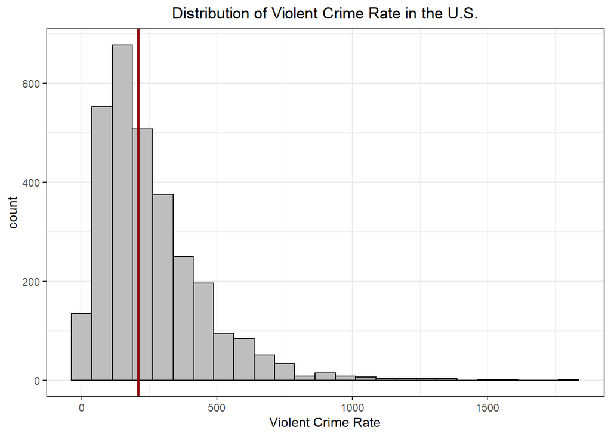

```r
#histogram of violent crime rate variable
p_violence <- dat %>% ggplot(aes(x = `Violent.Crime.Rate`)) +
              geom_histogram(binwidth = 75, color = "black", fill = "gray") +
              theme_bw()+
              ggtitle("Distribution of Violent Crime Rate in the U.S.") +
              theme(plot.title = element_text(hjust = 0.5)) +
              xlab("Violent Crime Rate")
#code to add line where the mean value is located
p_violence + geom_vline(aes(xintercept = median(`Violent.Crime.Rate`, na.rm = TRUE)), col='dark red',size=1)
```

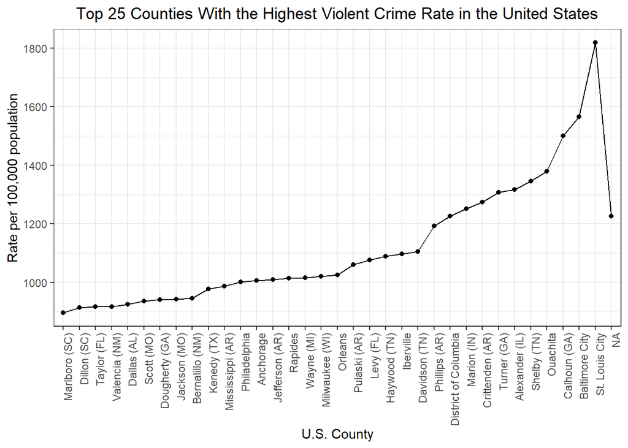

```r
#code for distribution statistics
#median(dat$`Violent.Crime.Rate`, na.rm = TRUE)
#IQR(dat$`Violent.Crime.Rate`, na.rm = TRUE)

#selecting the top 25 counties with the highest violence crime rate
p20 <- dat %>% select(county, state, `Violent.Crime.Rate`) %>% arrange(desc(`Violent.Crime.Rate`))%>%
              filter(`Violent.Crime.Rate` > 894)

#line plot for violent crime rate in the top 25 counties
p21 <- p20 %>% ggplot(aes(x = reorder(county, `Violent.Crime.Rate`), y = `Violent.Crime.Rate`, group = 1)) +
            geom_point() +
            geom_line() +
            theme_bw() +
            ggtitle("Top 25 Counties With the Highest Violent Crime Rate in the United States") +
            theme(plot.title = element_text(hjust = 0.5)) +
            theme(axis.text.x = element_text(angle = 90, hjust = 1)) +
            xlab("U.S County") + ylab("Rate per 100,000 population")

#adding state abbreviations to county line plot
p21 + scale_x_discrete("U.S. County", labels = c("Calhoun" = "Calhoun (GA)", "Shelby" = "Shelby (TN)", "Alexander" = "Alexander (IL)", "Turner" = "Turner (GA)", "Crittenden" = "Crittenden (AR)", "Marion" = "Marion (IN)", "Phillips" = "Phillips (AR)", "Davidson" = "Davidson (TN)", "Haywood" = "Haywood (TN)", "Levy" = "Levy (FL)", "Pulaski" = "Pulaski (AR)", "Milwaukee" = "Milwaukee (WI)", "Wayne" = "Wayne (MI)", "Jefferson" = "Jefferson (AR)", "Mississippi" = "Mississippi (AR)", "Kenedy" = "Kenedy (TX)", "Bernalillo" = "Bernalillo (NM)", "Jackson" = "Jackson (MO)", "Dougherty" = "Dougherty (GA)", "Scott" = "Scott (MO)", "Dallas" = "Dallas (AL)", "Valencia" = "Valencia (NM)", "Taylor" = "Taylor (FL)", "Dillon" = "Dillon (SC)", "Marlboro" = "Marlboro (SC)"))
```

## Analysis 2.12: Insufficient Sleep

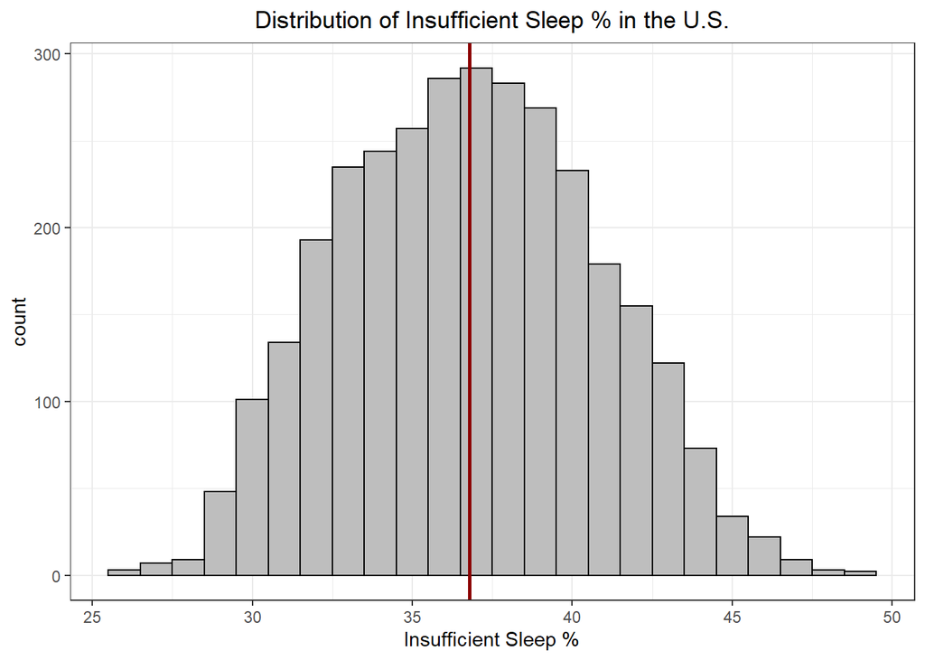

```r
#histogram of insufficient sleep variable
p_sleep <- dat %>% ggplot(aes(x = `%.Insufficient.Sleep`)) +
              geom_histogram(binwidth = 1, color = "black", fill = "gray") +
              theme_bw()+
              ggtitle("Distribution of Insufficient Sleep % in the U.S.") +
              theme(plot.title = element_text(hjust = 0.5)) +
              xlab("Insufficient Sleep %")

#code to add line where the mean value is located
p_sleep + geom_vline(aes(xintercept = mean(`%.Insufficient.Sleep`, na.rm = TRUE)), col='dark red',size=1)
```

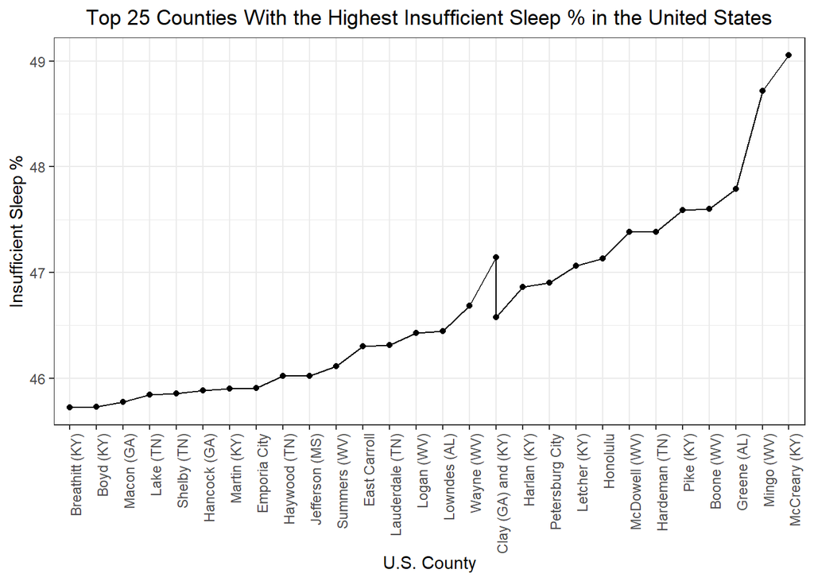

```r
#code for distribution statistics
#mean(dat$`%.Insufficient.Sleep`, na.rm = TRUE)
#sd(dat$`%.Insufficient.Sleep`, na.rm = TRUE)

#selecting the top 25 counties with the highest values of insufficient sleep
p22 <- dat %>% select(county, state, `%.Insufficient.Sleep`) %>% arrange(desc(`%.Insufficient.Sleep`))%>%
              filter(`%.Insufficient.Sleep` > 45.7)

#line plot for insufficient sleep in the top 25 counties
p23 <- p22 %>% ggplot(aes(x = reorder(county, `%.Insufficient.Sleep`), y = `%.Insufficient.Sleep`, group = 1)) +
            geom_point() +
            geom_line() +
            theme_bw() +
            ggtitle("Top 25 Counties With the Highest Insufficient Sleep % in the United States") +
            theme(plot.title = element_text(hjust = 0.5)) +
            theme(axis.text.x = element_text(angle = 90, hjust = 1)) +
            xlab("U.S County") + ylab("Insufficient Sleep %")

#adding state abbreviations to county line plot
p23 + scale_x_discrete("U.S. County", labels = c("McCreary" = "McCreary (KY)", "Mingo" = "Mingo (WV)", "Greene" = "Greene (AL)", "Boone" = "Boone (WV)", "Pike" = "Pike (KY)", "Hardeman" = "Hardeman (TN)", "McDowell" = "McDowell (WV)", "Clay" = "Clay (KY)", "Letcher" = "Letcher (KY)", "Harlan" = "Harlan (KY)", "Wayne" = "Wayne (WV)", "Clay" = "Clay (GA) and (KY)", "Lowndes" = "Lowndes (AL)", "Logan" = "Logan (WV)", "Lauderdale" = "Lauderdale (TN)", "Summers" = "Summers (WV)", "Jefferson" = "Jefferson (MS)", "Haywood" = "Haywood (TN)", "Martin" = "Martin (KY)", "Hancock" = "Hancock (GA)", "Shelby" = "Shelby (TN)", "Lake" = "Lake (TN)", "Macon" = "Macon (GA)", "Boyd" = "Boyd (KY)", "Breathitt" = "Breathitt (KY)"))
```

## Analysis 2.13: Average Daily PM 2.5

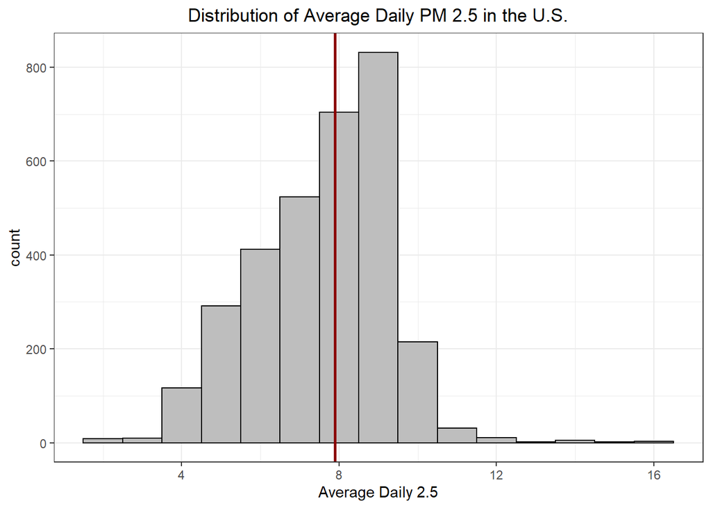

```r
#histogram of average daily PM 2.5 values
p_pm <- dat %>% ggplot(aes(x = Average.Daily.PM2.5)) +
              geom_histogram(binwidth = 1, color = "black", fill = "gray") +
              theme_bw()+
              ggtitle("Distribution of Average Daily PM 2.5 in the U.S.") +
              theme(plot.title = element_text(hjust = 0.5)) +
              xlab("Average Daily 2.5")

#code to add line where the median value is located
p_pm + geom_vline(aes(xintercept = median(Average.Daily.PM2.5, na.rm = TRUE)), col='dark red',size=1)
```

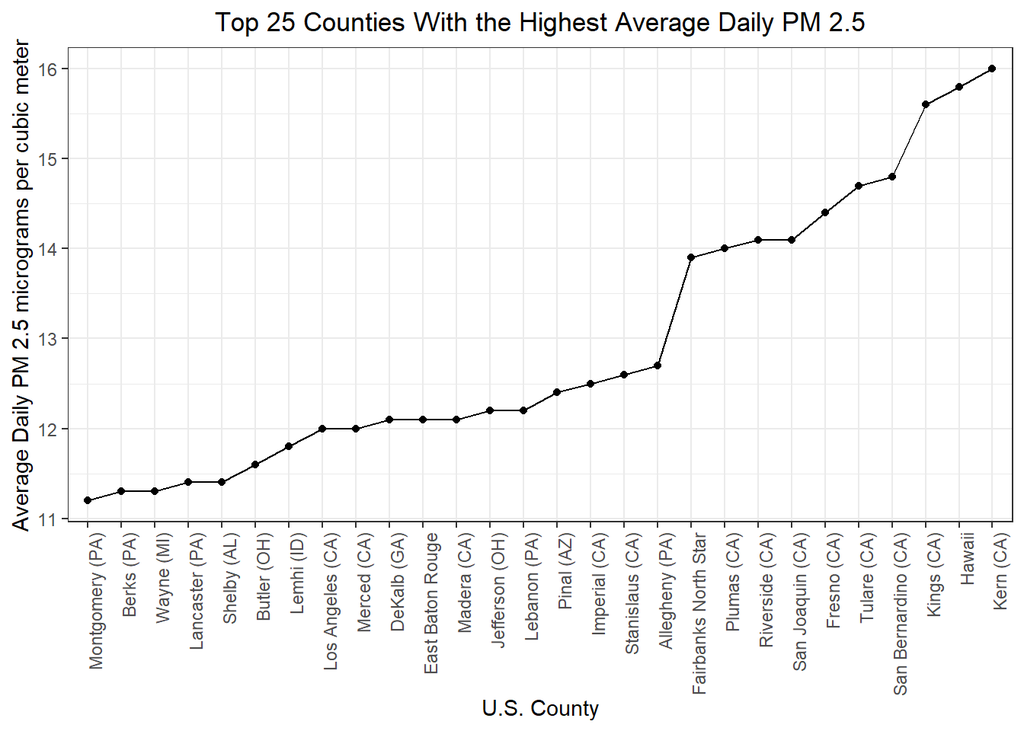

```r
#code for distribution statistics
#median(dat$Average.Daily.PM2.5, na.rm = TRUE)
#IQR(dat$Average.Daily.PM2.5, na.rm = TRUE)

#selecting the top 25 counties with the highest pm 2.5 values
p24 <- dat %>% select(county, state, Average.Daily.PM2.5) %>% arrange(desc(Average.Daily.PM2.5))%>%
              filter(Average.Daily.PM2.5 > 11.1)

#code for the average daily pm 2.5 values in ascending order with top 25 counties
p25 <- p24 %>% ggplot(aes(x = reorder(county, Average.Daily.PM2.5), y = Average.Daily.PM2.5, group = 1)) +
            geom_point() +
            geom_line() +
            theme_bw() +
            ggtitle("Top 25 Counties With the Highest Average Daily PM 2.5") +
            theme(plot.title = element_text(hjust = 0.5)) +
            theme(axis.text.x = element_text(angle = 90, hjust = 1)) +
            xlab("U.S County") + ylab("Average Daily PM 2.5 micrograms per cubic meter")

#adding state abbreviations to county line plot
p25 + scale_x_discrete("U.S. County", labels = c("Kern" = "Kern (CA)", "Kings" = "Kings (CA)", "San Bernardino" = "San Bernardino (CA)", "Tulare" = "Tulare (CA)", "Fresno" = "Fresno (CA)", "Riverside" = "Riverside (CA)", "San Joaquin" = "San Joaquin (CA)", "Plumas" = "Plumas (CA)", "Allegheny" = "Allegheny (PA)", "Stanislaus" = "Stanislaus (CA)", "Imperial" = "Imperial (CA)", "Pinal" = "Pinal (AZ)", "Jefferson" = "Jefferson (OH)", "Lebanon" = "Lebanon (PA)", "Madera" = "Madera (CA)", "DeKalb" = "DeKalb (GA)", "Los Angeles" = "Los Angeles (CA)", "Merced" = "Merced (CA)", "Lemhi" = "Lemhi (ID)", "Butler" = "Butler (OH)", "Shelby" = "Shelby (AL)", "Lancaster" = "Lancaster (PA)", "Wayne" = "Wayne (MI)", "Berks" = "Berks (PA)", "Montgomery" = "Montgomery (PA)"))
```

## Analysis 2.14: Median Household Income

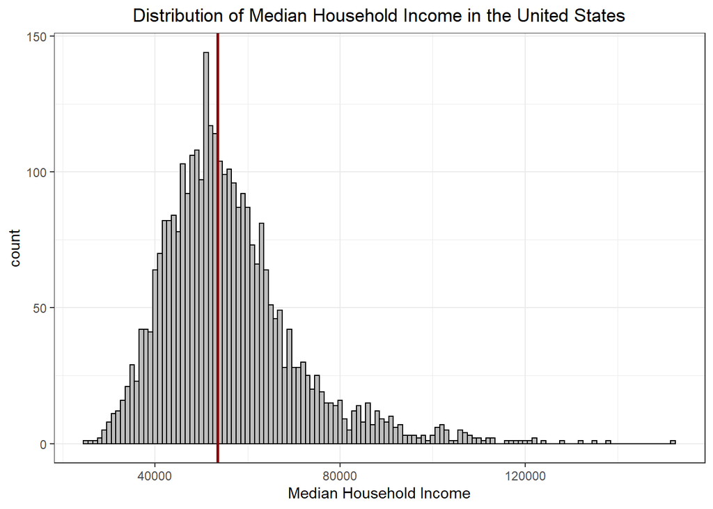

```r
#histogram of median household income
p_income <- dat %>% ggplot(aes(x = Median.Household.Income)) +
              geom_histogram(binwidth = 1000, color = "black", fill = "gray") +
              theme_bw()+
              ggtitle("Distribution of Median Household Income in the United States") +
              theme(plot.title = element_text(hjust = 0.5)) +
              xlab("Median Household Income")

#addition a line where the median value is located
p_income + geom_vline(aes(xintercept = median(Median.Household.Income, na.rm = TRUE)), col='dark red',size=1)
```

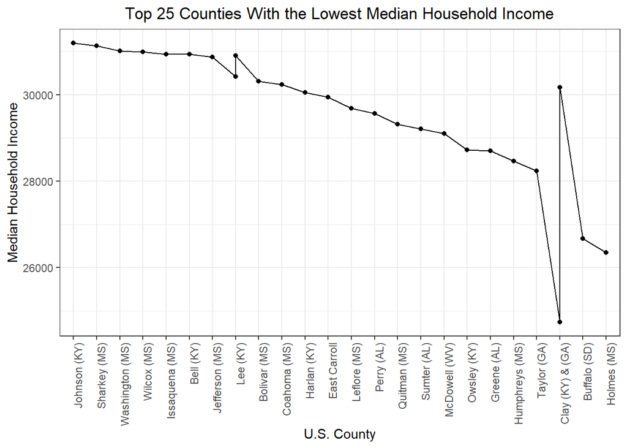

```r
#code for distribution statistics
#median(dat$Median.Household.Income, na.rm = TRUE)
#IQR(dat$Median.Household.Income, na.rm = TRUE)


#code to determine the top 25 counties with the lowest median household income
p26 <- dat %>% select(county, state, Median.Household.Income) %>% arrange(Median.Household.Income)%>%
              filter(Median.Household.Income < 31221)

#line plot in decsending order of median household income with the top 25 counties
p27 <- p26 %>% ggplot(aes(x = reorder(county, -Median.Household.Income), y = Median.Household.Income, group = 1)) +
            geom_point() +
            geom_line() +
            theme_bw() +
            ggtitle("Top 25 Counties With the Lowest Median Household Income") +
            theme(plot.title = element_text(hjust = 0.5)) +
            theme(axis.text.x = element_text(angle = 90, hjust = 1)) +
            xlab("U.S County") + ylab("Median Household Income")

#adding state abbreviations to county line plot
p27 + scale_x_discrete("U.S. County", labels = c("Clay" = "Clay (GA) & (KY)", "Holmes" = "Holmes (MS)", "Buffalo" = "Buffalo (SD)", "Taylor" = "Taylor (GA)", "Humphreys" = "Humphreys (MS)", "Greene" = "Greene (AL)", "Owsley" = "Owsley (KY)", "McDowell" = "McDowell (WV)", "Sumter" = "Sumter (AL)", "Quitman" = "Quitman (MS)", "Perry" = "Perry (AL)", "Leflore" = "Leflore (MS)", "Harlan" = "Harlan (KY)", "Clay" = "Clay (KY) & (GA)", "Coahoma" = "Coahoma (MS)", "Bolivar" = "Bolivar (MS)", "Lee" = "Lee (AR)", "Jefferson" = "Jefferson (MS)", "Lee" = "Lee (KY)", "Bell" = "Bell (KY)", "Issaquena" = "Issaquena (MS)", "Wilcox" = "Wilcox (MS)", "Washington" = "Washington (MS)", "Sharkey" = "Sharkey (MS)", "Johnson" = "Johnson (KY)"))
```

Outcome:

Our two primary outcomes were life expectancy and drug overdose mortality rate per 100,000 population. We created visualizations of the distribution of each outcome across the United States, by state, and then we determined the top 25 counties with the lowest life expectancy and the top 25 counties with the highest drug overdose mortality rate. We prioritized the histogram and line plots of the 25 counties for each predictor because our overall predictions were using county-level data. Depending on the distribution of the histogram of the variable of interest, the mean and the standard deviation were calculated, or the median and the interquartile range were calculated. We chose these metrics as these are the standard ways to summarize the distribution of variable. As we had county level data, we wanted to ensure that our analyses had a focus at the country level. there were no major changes to our initial ideas. We also wanted to show the relationship between our two main outcome variables, and that is why the scatter plot with the trend line was generated.

# Analysis 3: Prediction models

## Analysis 3.1: linear regression

## The goal of this section was to identify the machine learning model that best predicts the outcomes of interest

The built environment and place-based policies play important roles in life expectancy. They are also important factors in many of the epidemics facing America, including drug-related overdose mortality. It would be helpful to know what factors related to county-level characteristics help to predict differences in life expectancies and drug-related overdose mortality.

Approach: To run a simple linear regression model to understand what covariates might be significant and then to use correlation plots to pick up on potential collinearities and identify modifiable predictors that are still highly correlated with the outcomes of interest to include in the machine learning prediction models. Selected covariates for the machine learning models were based on subject matter knowledge, expectations of modifiability with government/grassroots intervention, and strengths of association from linear models and correlation plots.

Inspiration: Class sessions on logistic models, Naive Bayes, and Decision trees informed the prediction modeling approach. The outcomes were dichotomized as being below or above average life expectancy and drug overdose mortality respectively.

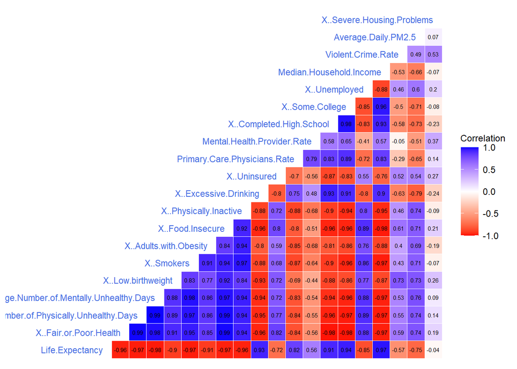

```r
# prediction model

# We will be using data from the county health rankings to explore predictors for life expectancy using the following variables:

# Fair or Poor Health
# Average number of physically unhealthy days
# Average number of mentally unhealthy days
# low birthweight
# smoking status
# adults with obesity
# food environment index
# mental health provider rate
# percent completed high school
# percent completed college
# percent unemployed
# violent crime rate
# average daily PM 2.5
# Severe housing problems
# Median Household Income

# subset data to use for prediction model

pred_dat <- dat %>% select(Life.Expectancy, `%.Fair.or.Poor.Health`, `Average.Number.of.Physically.Unhealthy.Days`, `Average.Number.of.Mentally.Unhealthy.Days`,    `%.Low.birthweight`,    `%.Smokers`, `%.Adults.with.Obesity`,   `%.Food.Insecure`,  `%.Physically.Inactive`,    `%.Excessive.Drinking`, `%.Uninsured`, `Primary.Care.Physicians.Rate`,  Mental.Health.Provider.Rate,    `%.Completed.High.School`, `%.Some.College`,    `%.Unemployed`, Median.Household.Income, Violent.Crime.Rate, Average.Daily.PM2.5, `%.Severe.Housing.Problems`) %>% arrange(Life.Expectancy) %>% drop_na()

# create correlation plot

library(GGally)
library(ggplot2)
corr <- cor(pred_dat)
ggcorr(corr,
       label = T,
       label_size = 2,
       label_round = 2,
       hjust = 1,
       size = 3,
       color = "royalblue",
       layout.exp = 5,
       low = "red",
       mid = "white",
       high = "blue",
       name = "Correlation")
```

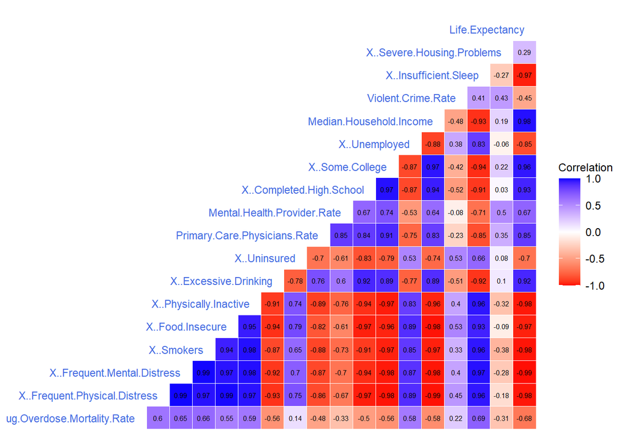

```r
# We will be using data from the county health rankings to explore predictors for the drug-related overdose mortality outcomes using the following variables:

# Frequent.Physical.Distress
# Frequent.Mental.Distress
# percentage of Smokers
# percentage Food Insecure
# percentage Physically Inactive
# percentage Excessive Drinking
# percentage Uninsured
# Primary.Care.Physicians.Rate
# Mental.Health.Provider.Rate
# percentage Completed.High.School
# percentage completed Some.College
# percentage Unemployed
# SES, Median.Household.Income
# Violent.Crime.Rate
# percentage Insufficient.Sleep
# percentage Severe.Housing.Problems
# Life.Expectancy

# subset prediction data

pred_dat2 <- dat %>% select(Drug.Overdose.Mortality.Rate,`%.Frequent.Physical.Distress`, `%.Frequent.Mental.Distress`,  `%.Smokers`, `%.Food.Insecure`, `%.Physically.Inactive`,    `%.Excessive.Drinking`, `%.Uninsured`, `Primary.Care.Physicians.Rate`,  Mental.Health.Provider.Rate,    `%.Completed.High.School`, `%.Some.College`,    `%.Unemployed`, Median.Household.Income, Violent.Crime.Rate, `%.Insufficient.Sleep`, `%.Severe.Housing.Problems`, Life.Expectancy) %>% arrange(Drug.Overdose.Mortality.Rate) %>% drop_na()

# correlation plot
corr2 <- cor(pred_dat2)
ggcorr(corr2,
       label = T,
       label_size = 2,
       label_round = 2,
       hjust = 1,
       size = 3,
       color = "royalblue",
       layout.exp = 5,
       low = "red",
       mid = "white",
       high = "blue",
       name = "Correlation")
```

```r
# fit linear prediction model for life expectancy

pred_fit <- glm(Life.Expectancy ~ ., data=pred_dat)
summary(pred_fit)
```

```
##
## Call:
## glm(formula = Life.Expectancy ~ ., data = pred_dat)
##
## Deviance Residuals:
##     Min       1Q   Median       3Q      Max
## -9.9852  -0.8194  -0.0253   0.7960  20.3791
##
## Coefficients:
##                                               Estimate Std. Error t value
## (Intercept)                                  8.746e+01  1.527e+00  57.283
## `%.Fair.or.Poor.Health`                      7.040e-02  3.176e-02   2.216
## Average.Number.of.Physically.Unhealthy.Days -5.398e-01  1.869e-01  -2.888
## Average.Number.of.Mentally.Unhealthy.Days   -1.141e-01  1.456e-01  -0.784
## `%.Low.birthweight`                         -1.315e-01  2.316e-02  -5.681
## `%.Smokers`                                 -2.284e-01  1.909e-02 -11.965
## `%.Adults.with.Obesity`                     -5.576e-02  7.467e-03  -7.467
## `%.Food.Insecure`                           -1.589e-01  2.175e-02  -7.303
## `%.Physically.Inactive`                     -4.812e-02  8.420e-03  -5.715
## `%.Excessive.Drinking`                       8.711e-02  1.563e-02   5.574
## `%.Uninsured`                               -9.133e-03  9.844e-03  -0.928
## Primary.Care.Physicians.Rate                 1.035e-03  1.195e-03   0.866
## Mental.Health.Provider.Rate                 -9.665e-04  2.257e-04  -4.282
## `%.Completed.High.School`                    5.736e-03  1.333e-02   0.430
## `%.Some.College`                            -9.192e-03  5.606e-03  -1.640
## `%.Unemployed`                               1.270e-01  3.275e-02   3.878
## Median.Household.Income                      1.540e-05  4.008e-06   3.842
## Violent.Crime.Rate                          -1.472e-03  1.952e-04  -7.541
## Average.Daily.PM2.5                         -7.471e-02  2.348e-02  -3.182
## `%.Severe.Housing.Problems`                  6.412e-02  1.074e-02   5.972
##                                             Pr(>|t|)
## (Intercept)                                  < 2e-16 ***
## `%.Fair.or.Poor.Health`                     0.026746 *
## Average.Number.of.Physically.Unhealthy.Days 0.003906 **
## Average.Number.of.Mentally.Unhealthy.Days   0.433159
## `%.Low.birthweight`                         1.49e-08 ***
## `%.Smokers`                                  < 2e-16 ***
## `%.Adults.with.Obesity`                     1.10e-13 ***
## `%.Food.Insecure`                           3.71e-13 ***
## `%.Physically.Inactive`                     1.22e-08 ***
## `%.Excessive.Drinking`                      2.74e-08 ***
## `%.Uninsured`                               0.353583
## Primary.Care.Physicians.Rate                0.386629
## Mental.Health.Provider.Rate                 1.92e-05 ***
## `%.Completed.High.School`                   0.667076
## `%.Some.College`                            0.101189
## `%.Unemployed`                              0.000108 ***
## Median.Household.Income                     0.000125 ***
## Violent.Crime.Rate                          6.36e-14 ***
## Average.Daily.PM2.5                         0.001482 **
## `%.Severe.Housing.Problems`                 2.66e-09 ***
## ---
## Signif. codes:  0 '***' 0.001 '**' 0.01 '*' 0.05 '.' 0.1 ' ' 1
##
## (Dispersion parameter for gaussian family taken to be 2.661928)
##
##     Null deviance: 22509.0  on 2679  degrees of freedom
## Residual deviance:  7080.7  on 2660  degrees of freedom
## AIC: 10251
##
## Number of Fisher Scoring iterations: 2
```

```r
# fit linear prediction model for overdose mortality

pred_fit2 <- glm(Drug.Overdose.Mortality.Rate ~ ., data=pred_dat2)
summary(pred_fit2)
```

```
##
## Call:
## glm(formula = Drug.Overdose.Mortality.Rate ~ ., data = pred_dat2)
##
## Deviance Residuals:
##     Min       1Q   Median       3Q      Max
## -24.466   -6.271   -1.537    5.032   79.425
##
## Coefficients:
##                                  Estimate Std. Error t value Pr(>|t|)
## (Intercept)                     2.008e+02  1.911e+01  10.510  < 2e-16 ***
## `%.Frequent.Physical.Distress` -3.497e+00  4.307e-01  -8.119 8.87e-16 ***
## `%.Frequent.Mental.Distress`    4.402e+00  4.553e-01   9.667  < 2e-16 ***
## `%.Smokers`                    -1.659e-01  1.698e-01  -0.977  0.32877
## `%.Food.Insecure`              -9.643e-01  1.776e-01  -5.431 6.42e-08 ***
## `%.Physically.Inactive`        -2.938e-01  6.955e-02  -4.224 2.53e-05 ***
## `%.Excessive.Drinking`          1.190e-02  1.139e-01   0.104  0.91681
## `%.Uninsured`                  -3.850e-01  7.771e-02  -4.954 7.98e-07 ***
## Primary.Care.Physicians.Rate    1.488e-02  8.952e-03   1.662  0.09664 .
## Mental.Health.Provider.Rate     4.984e-03  1.739e-03   2.866  0.00421 **
## `%.Completed.High.School`       6.316e-02  9.269e-02   0.681  0.49569
## `%.Some.College`               -8.515e-02  4.825e-02  -1.765  0.07780 .
## `%.Unemployed`                  1.596e+00  2.703e-01   5.903 4.29e-09 ***
## Median.Household.Income         1.286e-04  3.088e-05   4.163 3.30e-05 ***
## Violent.Crime.Rate              1.251e-03  1.394e-03   0.897  0.36975
## `%.Insufficient.Sleep`          5.394e-01  1.063e-01   5.077 4.26e-07 ***
## `%.Severe.Housing.Problems`     5.981e-01  9.613e-02   6.222 6.18e-10 ***
## Life.Expectancy                -2.783e+00  1.886e-01 -14.759  < 2e-16 ***
## ---
## Signif. codes:  0 '***' 0.001 '**' 0.01 '*' 0.05 '.' 0.1 ' ' 1
##
## (Dispersion parameter for gaussian family taken to be 97.28097)
##
##     Null deviance: 259579  on 1727  degrees of freedom
## Residual deviance: 166350  on 1710  degrees of freedom
## AIC: 12834
##
## Number of Fisher Scoring iterations: 2
```

```r
# identify average life expectancy and overdose mortality to dichotomize variables
avg.overdose <- mean(pred_dat2$Drug.Overdose.Mortality.Rate)
avg.overdose
```

```
## [1] 22.60334
```

```r
avg.life <- mean(pred_dat$Life.Expectancy)
avg.life
```

```
## [1] 77.56183
```

```r
# create data sets with dichotomized variables for outcomes of interest

pred_dat <- pred_dat %>% mutate(life_exp = ifelse(Life.Expectancy >= avg.life, 0, 1))

pred_dat2 <- pred_dat2 %>% mutate(overdose = ifelse(Drug.Overdose.Mortality.Rate >= avg.overdose, 1, 0))
```

## Analysis 3.2: machine learning models

```r
# prediction models

library(tidyverse)
library(splitstackshape)
library(caret)
library(e1071)
library(pROC)
```

```r
library(dplyr)
library(ggplot2)
remotes::update_packages("rlang")
```

```r
set.seed(1)

# come up with training and test sets
x <- stratified(pred_dat, "life_exp", 0.7, keep.rownames = TRUE)
train_set <- x %>% dplyr::select(-rn)
train_index <- as.numeric(x$rn)
test_set <- pred_dat[-train_index,]

dim(train_set)
```

```
## [1] 1876   21
```

```r
dim(test_set)
```

```
## [1] 804  21
```

```r
## Logistic regression model (covariates selected based on relevance to policy/decision-making and correlation to outcomes)
fit <-  glm(life_exp ~ `%.Food.Insecure` +  `%.Uninsured` + `%.Some.College` +  `%.Unemployed` +    Median.Household.Income + Violent.Crime.Rate + Average.Daily.PM2.5 + `%.Severe.Housing.Problems`, data= train_set, family="binomial")

p_hat <- predict(fit, newdata = test_set, type="response")
y_hat <- ifelse(p_hat > 0.5, 1, 0)

# confusion matrix
CF <- confusionMatrix(data = as.factor(y_hat), reference = as.factor(test_set$life_exp), positive = '1')
CF
```

```
## Confusion Matrix and Statistics
##
##           Reference
## Prediction   0   1
##          0 352  64
##          1  57 331
##
##                Accuracy : 0.8495
##                  95% CI : (0.8229, 0.8735)
##     No Information Rate : 0.5087
##     P-Value [Acc > NIR] : <2e-16
##
##                   Kappa : 0.6988
##
##  Mcnemar's Test P-Value : 0.5854
##
##             Sensitivity : 0.8380
##             Specificity : 0.8606
##          Pos Pred Value : 0.8531
##          Neg Pred Value : 0.8462
##              Prevalence : 0.4913
##          Detection Rate : 0.4117
##    Detection Prevalence : 0.4826
##       Balanced Accuracy : 0.8493
##
##        'Positive' Class : 1
##
```

```r
## Naive Bayes model
set.seed(1)
nb_fit <-  naiveBayes(life_exp ~ `%.Food.Insecure` +    `%.Uninsured` + `%.Some.College` +  `%.Unemployed` +    Median.Household.Income + Violent.Crime.Rate + Average.Daily.PM2.5 + `%.Severe.Housing.Problems`, data = train_set)

p_hat_nb <- predict(nb_fit, test_set, type = "raw")[,2]
y_hat_nb <- factor(ifelse(p_hat_nb > 0.5, 1, 0))

# confusion matrix
CFnb <- confusionMatrix(data = as.factor(y_hat_nb), reference = as.factor(test_set$life_exp), positive = '1')
CFnb
```

```
## Confusion Matrix and Statistics
##
##           Reference
## Prediction   0   1
##          0 344  65
##          1  65 330
##
##                Accuracy : 0.8383
##                  95% CI : (0.811, 0.8631)
##     No Information Rate : 0.5087
##     P-Value [Acc > NIR] : <2e-16
##
##                   Kappa : 0.6765
##
##  Mcnemar's Test P-Value : 1
##
##             Sensitivity : 0.8354
##             Specificity : 0.8411
##          Pos Pred Value : 0.8354
##          Neg Pred Value : 0.8411
##              Prevalence : 0.4913
##          Detection Rate : 0.4104
##    Detection Prevalence : 0.4913
##       Balanced Accuracy : 0.8383
##
##        'Positive' Class : 1
##
```

```r
## decision tree model
library(rpart)
set.seed(1)
train_set <- train_set  %>% dplyr::select(., life_exp, `%.Food.Insecure` ,  `%.Uninsured` , `%.Some.College` ,  `%.Unemployed`, Median.Household.Income , Violent.Crime.Rate , Average.Daily.PM2.5 , `%.Severe.Housing.Problems`)
tree_fit <- rpart(as.factor(life_exp) ~ ., data = train_set)
tree_preds <- predict(tree_fit, newdata = test_set, type = "class")

# confusion matrix
CFtree <- confusionMatrix(data = as.factor(tree_preds), reference = as.factor(test_set$life_exp), positive='1')
CFtree
```

```
## Confusion Matrix and Statistics
##
##           Reference
## Prediction   0   1
##          0 319  77
##          1  90 318
##
##                Accuracy : 0.7923
##                  95% CI : (0.7626, 0.8198)
##     No Information Rate : 0.5087
##     P-Value [Acc > NIR] : <2e-16
##
##                   Kappa : 0.5847
##
##  Mcnemar's Test P-Value : 0.3531
##
##             Sensitivity : 0.8051
##             Specificity : 0.7800
##          Pos Pred Value : 0.7794
##          Neg Pred Value : 0.8056
##              Prevalence : 0.4913
##          Detection Rate : 0.3955
##    Detection Prevalence : 0.5075
##       Balanced Accuracy : 0.7925
##
##        'Positive' Class : 1
##
```

```r
# logistic life exp

roc_log <- roc(test_set$life_exp, y_hat)
# nb life exp

roc_nb <- roc(as.factor(test_set$life_exp), p_hat_nb)
# decision tree life exp
tree_preds <- predict(tree_fit, newdata = test_set, type = "prob")[,2]
roc_dt <- roc(test_set$life_exp, tree_preds)
```

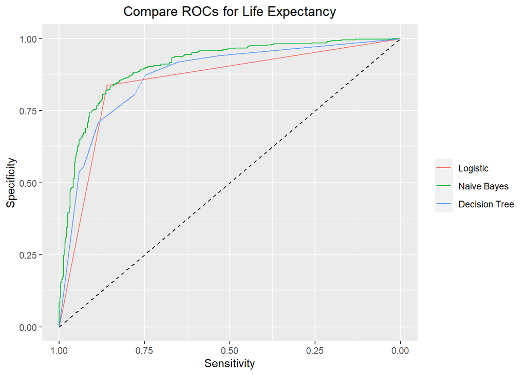

```r
# ROCs for life expectancy

ggroc(list("Logistic" = roc_log, "Naive Bayes" = roc_nb, "Decision Tree" = roc_dt)) +
  theme(legend.title = element_blank()) +
  geom_segment(aes(x = 1, xend = 0, y = 0, yend = 1), color = "black", linetype = "dashed") +
  xlab("Sensitivity") +
  ylab("Specificity")+
  ggtitle("Compare ROCs for Life Expectancy")+
  theme(plot.title = element_text(hjust = 0.5))
```

```r
# overdose mortality

# creat training and test sets

x2 <- stratified(pred_dat2, "overdose", 0.7, keep.rownames = TRUE)
train_set2 <- x2 %>% dplyr::select(-rn)
train_index2 <- as.numeric(x2$rn)
test_set2 <- pred_dat2[-train_index2,]

dim(train_set2)
```

```
## [1] 1209   19
```

```r
dim(test_set2)
```

```
## [1] 519  19
```

```r
## Logistic regression model (covariates selected based on relevance to policy/decision-making and correlation to outcomes)
fit2 <-  glm(overdose ~ `%.Food.Insecure`+  `%.Uninsured`+  `%.Some.College`+   `%.Unemployed`+ Median.Household.Income+ Violent.Crime.Rate+ `%.Insufficient.Sleep`, `%.Severe.Housing.Problems`, data= train_set2, family="binomial")
p_hat2 <- predict(fit2, newdata = test_set2, type="response")
y_hat2 <- ifelse(p_hat2 > 0.5, 1, 0)

# confusion matrix
CF2 <- confusionMatrix(data = as.factor(y_hat2), reference = as.factor(test_set2$overdose), positive = '1')
CF2
```

```
## Confusion Matrix and Statistics
##
##           Reference
## Prediction   0   1
##          0 240  99
##          1  70 110
##
##                Accuracy : 0.6744
##                  95% CI : (0.6322, 0.7146)
##     No Information Rate : 0.5973
##     P-Value [Acc > NIR] : 0.000174
##
##                   Kappa : 0.3075
##
##  Mcnemar's Test P-Value : 0.031252
##
##             Sensitivity : 0.5263
##             Specificity : 0.7742
##          Pos Pred Value : 0.6111
##          Neg Pred Value : 0.7080
##              Prevalence : 0.4027
##          Detection Rate : 0.2119
##    Detection Prevalence : 0.3468
##       Balanced Accuracy : 0.6503
##
##        'Positive' Class : 1
##
```

```r
## Naive Bayes model
set.seed(1)
nb_fit2 <-  naiveBayes(overdose ~ `%.Food.Insecure`+    `%.Uninsured`+  `%.Some.College`+   `%.Unemployed`+ Median.Household.Income+ Violent.Crime.Rate+ `%.Insufficient.Sleep`+ `%.Severe.Housing.Problems`, data = train_set2)

p_hat_nb2 <- predict(nb_fit2, test_set2, type = "raw")[,2]
y_hat_nb2 <- factor(ifelse(p_hat_nb2 > 0.5, 1, 0))

# confusion matrix
CFnb2 <- confusionMatrix(data = as.factor(y_hat_nb2), reference = as.factor(test_set2$overdose), positive = '1')
CFnb2
```

```
## Confusion Matrix and Statistics
##
##           Reference
## Prediction   0   1
##          0 199  88
##          1 111 121
##
##                Accuracy : 0.6166
##                  95% CI : (0.5732, 0.6586)
##     No Information Rate : 0.5973
##     P-Value [Acc > NIR] : 0.1978
##
##                   Kappa : 0.217
##
##  Mcnemar's Test P-Value : 0.1189
##
##             Sensitivity : 0.5789
##             Specificity : 0.6419
##          Pos Pred Value : 0.5216
##          Neg Pred Value : 0.6934
##              Prevalence : 0.4027
##          Detection Rate : 0.2331
##    Detection Prevalence : 0.4470
##       Balanced Accuracy : 0.6104
##
##        'Positive' Class : 1
##
```

```r
## decision tree model
library(rpart)
set.seed(1)
train_set2 <- train_set2  %>% dplyr::select(., overdose, `%.Food.Insecure`, `%.Uninsured`,  `%.Some.College`,   `%.Unemployed`, Median.Household.Income, Violent.Crime.Rate, `%.Insufficient.Sleep`, `%.Severe.Housing.Problems`)
tree_fit2 <- rpart(as.factor(overdose) ~ ., data = train_set2)
tree_preds2 <- predict(tree_fit2, newdata = test_set2, type = "class")

# confusion matrix
CFtree2 <- confusionMatrix(data = as.factor(tree_preds2), reference = as.factor(test_set2$overdose), positive='1')
CFtree2
```

```
## Confusion Matrix and Statistics
##
##           Reference
## Prediction   0   1
##          0 230  93
##          1  80 116
##
##                Accuracy : 0.6667
##                  95% CI : (0.6243, 0.7071)
##     No Information Rate : 0.5973
##     P-Value [Acc > NIR] : 0.0006652
##
##                   Kappa : 0.3
##
##  Mcnemar's Test P-Value : 0.3615881
##
##             Sensitivity : 0.5550
##             Specificity : 0.7419
##          Pos Pred Value : 0.5918
##          Neg Pred Value : 0.7121
##              Prevalence : 0.4027
##          Detection Rate : 0.2235
##    Detection Prevalence : 0.3776
##       Balanced Accuracy : 0.6485
##
##        'Positive' Class : 1
##
```

```r
# logistic overdose

roc_log2 <- roc(test_set2$overdose, y_hat2)
# nb overdose

roc_nb2 <- roc(as.factor(test_set2$overdose), p_hat_nb2)
# decision tree overdose
tree_preds2 <- predict(tree_fit2, newdata = test_set2, type = "prob")[,2]
roc_dt2 <- roc(test_set2$overdose, tree_preds2)
```

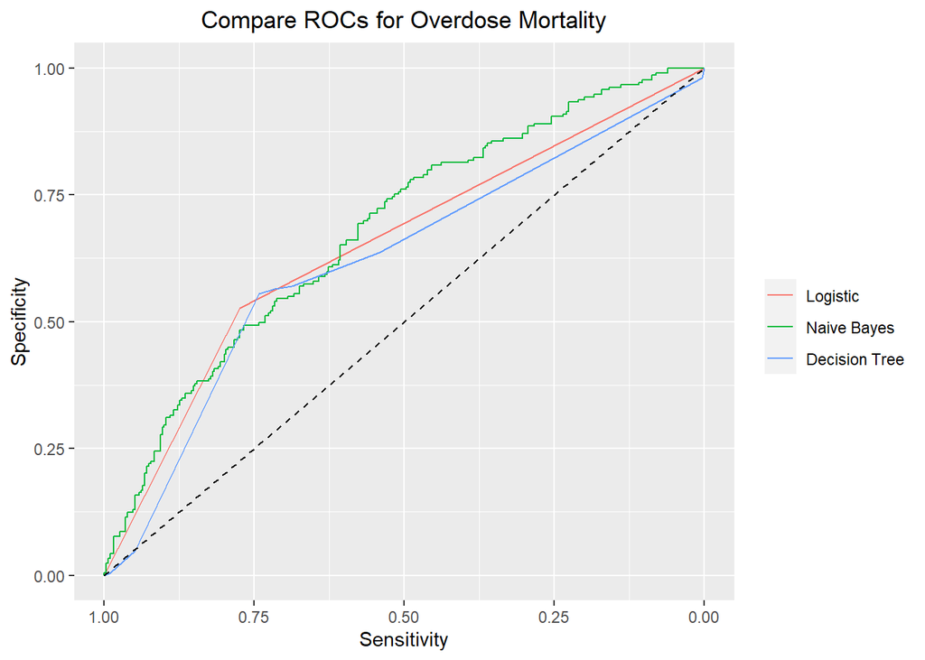

```r
# ROCs overdose

ggroc(list("Logistic" = roc_log2, "Naive Bayes" = roc_nb2, "Decision Tree" = roc_dt2)) +
  theme(legend.title = element_blank()) +
  geom_segment(aes(x = 1, xend = 0, y = 0, yend = 1), color = "black", linetype = "dashed") +
  xlab("Sensitivity") +
  ylab("Specificity")+
  ggtitle("Compare ROCs for Overdose Mortality")+
  theme(plot.title = element_text(hjust = 0.5))
```

## Analysis 3.3: identifying the best model and most important predictors

```r
# identifying best model

# areas under the curve
auc(roc_log)
```

```
## Area under the curve: 0.8493
```

```r
auc(roc_log2)
```

```
## Area under the curve: 0.6503
```

```r
auc(roc_nb)
```

```
## Area under the curve: 0.9052
```

```r
auc(roc_nb2)
```

```
## Area under the curve: 0.68
```

```r
auc(roc_dt)
```

```
## Area under the curve: 0.871
```

```r
auc(roc_dt2)
```

```
## Area under the curve: 0.6206
```

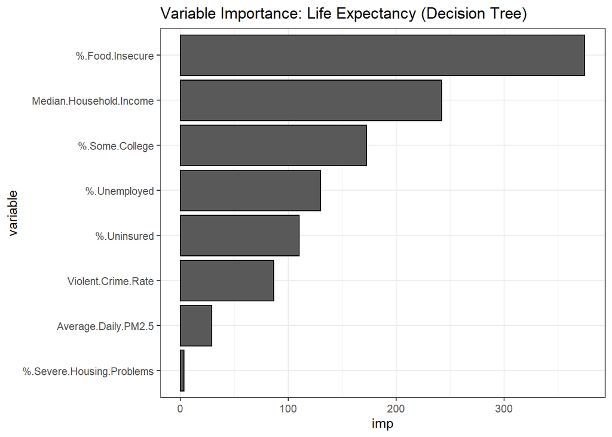

```r
# Variable importance from decision tree (life expectancy)

dat_imp <- data.frame(imp = tree_fit$variable.importance)
dat_imp <- dat_imp %>%
  tibble::rownames_to_column() %>%
  dplyr::rename("variable" = rowname) %>%
  dplyr::arrange(imp) %>%
  dplyr::mutate(variable = forcats::fct_inorder(variable))
ggplot2::ggplot(dat_imp) +
  geom_col(aes(x = variable, y = imp),
           col = "black", show.legend = FALSE) +
  coord_flip() +
  scale_fill_grey() +
  theme_bw() +
  ggtitle("Variable Importance: Life Expectancy (Decision Tree)")
```

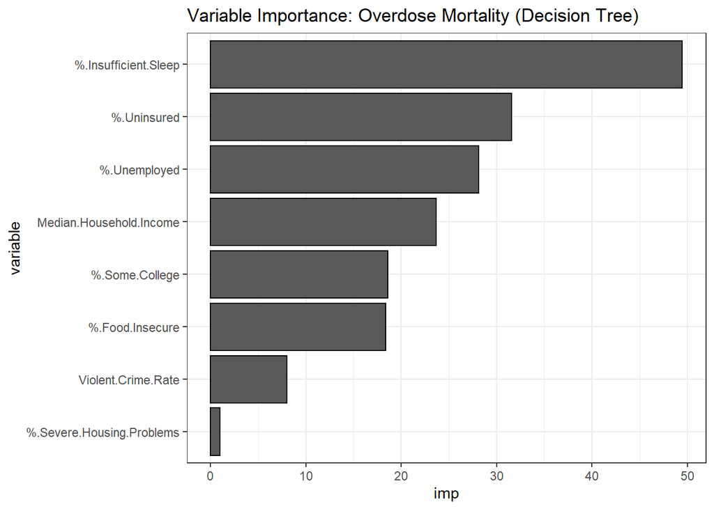

```r
# Variable importance from decision tree (overdose)

dat_imp2 <- data.frame(imp = tree_fit2$variable.importance)
dat_imp2 <- dat_imp2 %>%
  tibble::rownames_to_column() %>%
  dplyr::rename("variable" = rowname) %>%
  dplyr::arrange(imp) %>%
  dplyr::mutate(variable = forcats::fct_inorder(variable))
ggplot2::ggplot(dat_imp2) +
  geom_col(aes(x = variable, y = imp),
           col = "black", show.legend = FALSE) +
  coord_flip() +
  scale_fill_grey() +
  theme_bw() +
  ggtitle("Variable Importance: Overdose Mortality (Decision Tree)")
```

Table for life Expectancy Prediction models

| Model | Accuracy | Sensitivity | Specificity | AUC |  |
| --- | --- | --- | --- | --- | --- |
| Logistic | 0.85 | 0.838 | 0.861 | 0.849 |  |
| Naive Bayes | `0.838 | 0.835 | 0.841 | 0.905 |  |
| Decision Tree | 0.792 | 0.805 | 0.78 | 0.871 |  |

Table for Overdose Mortality Prediction models

| Model | Accuracy | Sensitivity | Specificity | AUC |  |
| --- | --- | --- | --- | --- | --- |
| Logistic | 0.674 | 0.526 | 0.774 | 0.65 |  |
| Naive Bayes | `0.617 | 0.579 | 0.642 | 0.68 |  |
| Decision Tree | 0.667 | 0.555 | 0.742 | 0.621 |  |

The three models are close in accuracy, sensitivity, and specificity with the logistic model having slightly higher accuracy for both life expectancy and overdose-related mortality outcomes. The Naive Bayes model has the highest AUC in both.

In the Decision Tree model for life expectancy, the accuracy (which is how often the classifier is overall correct) is 0.792. Sensitivity (true positive rate) is 0.8050633 and specificity (true negative rate) is 0.7799511. The test has somewhat high sensitivity and therefore a lower type II error rate (less false negatives or 1-sensitivity= 0.1949367 for the false negative rate). Since it has slightly lower (though still high) specificity, it has slightly higher type I error rates (more false positives or 1-specificity=0.2200489 for the false positive rate).

Using the decision tree model to understand variable importance in the model, we generated plots of descending importance. Variable importance looks at the relative influence of each of the included variables in the model and selects those that are split on during the tree building process and compares the improvement of squared errors (which is the difference in squared error between the node and its descendant nodes) as a result of the split.

It is important to note that our models are less accurate for drug-related overdose mortality and the relative importance of the predictors for this outcome is much lower as compared to life expectancy.

Sources: Lecture notes for machine learning (logistic regression, naive bayes, and decision trees), Stack Exchange, and Variable Importance resources found [here] (https://docs.h2o.ai/h2o/latest-stable/h2o-docs/variable-importance.html).